# Survival-Supervised Bayesian Matrix Factorization for Prognostic Molecular Programs in Pancreatic Cancer

Author

Andrew Walther

Published

October 16, 2026

# Summary

**Background and aim.** Bulk pancreatic tumors mix tumor, stromal and immune signals. We study whether Bayesian molecular-program models can distinguish these roles, predict survival across cohorts and integrate matched modalities.

**Method.** Empirical-Bayes factorization estimates patient activities and feature loadings; a Cox model uses projection scores computable for new patients. We evaluate single-block and joint expression–methylation models through simulations, held-out cohorts, feature expansion and biological characterization.

**Results.** The single-block benchmark achieves mean concordance 0.627 across five external dataset series (616 records, including repeated donors), versus 0.601 for factorization with a 40-factor cap followed by CV-tuned LASSO Cox regression. Four retained programs have basal-like/classical, stromal-associated and immune-associated expression patterns. Conditional training CV shows no consistent concordance gain through 17,900 genes, with strong program agreement from 5,001 to 10,000. Joint concordance is 0.685 versus expression-only 0.676 on 50 ICGC donors; both fits are unconverged and added methylation benefit is unproven.

**Conclusions.** Current evidence supports cross-cohort prediction and interpretable molecular structure. The benchmark uses $\alpha_F=0$: survival does not guide its loadings. Reliable survival-guided discovery, rank selection and reproducible added multimodal biology remain requirements for the intended final method.

# 1 Methods

## 1.1 Notation

Patients are indexed by $i = 1, \dots, n$, molecular features by $j$, factors (programs) by $k = 1, \dots, K$, and data blocks (modalities) by $m$. Patient $i$ has observed time $t_i$ and event indicator $\delta_i$ (1 for death, 0 for censoring). The single-modality data are an $n \times p$ matrix $Y$; the multimodal data are matched blocks $Y_m$ of dimension $n \times p_m$, here gene expression ($m = \mathrm{expr}$) and DNA methylation ($m = \mathrm{meth}$). The symbol $\beta$ is reserved for survival coefficients; methylation measurements are written $Y_{\mathrm{meth}}$. For any random quantity $\theta$ under the variational posterior $q$, $\bar\theta = E_q\theta$ and $\overline{\theta^2} = E_q\theta^2$.

Three patient-level quantities are kept apart. The **latent activities** $L \in \mathbb{R}_{\ge 0}^{n \times K}$ are posterior scores in the reconstruction $Y \approx LF^\top$ and exist only for training patients. The **projection scores** are the product of a patient’s data with the posterior-mean loadings; they enter the Cox predictor and can be computed for new patients. The **signature scores**, used only in biological characterization, are means of within-cohort standardized expression over a selected gene set. Table 1 summarizes how the two models differ.

Table 1: Differences between the single-modality and multimodal models. Both factor $n$ patients by $p$ features into nonnegative patient activities $L$ ($n \times K$) and feature loadings $F$ ($p \times K$) for $K$ factors, use point-exponential priors for $L$ and normal coefficient priors with variances estimated per factor by empirical Bayes, estimate feature-specific residual precisions by maximum likelihood, and link survival through a Cox proportional-hazards model. $\bar F$, posterior-mean loadings; $D_*$, diagonal matrix of the loading-column norms stored with the fit; $\mu_m$, feature intercepts; $\tilde Y_m = Y_m - \mathbf{1}\mu_m^\top$; expr, gene expression; meth, DNA methylation; SD, standard deviation; $\bar Z$, mean projection.

[output not shown]

## 1.2 Single-modality model

**Reconstruction and priors.** The training matrix is modeled as
$$y_{ij} = \sum_{k=1}^K L_{ik} F_{jk} + e_{ij}, \qquad e_{ij} \sim N(0, \tau_j^{-1}),
\tag{1}$$
with independent point-exponential priors $L_{ik} \sim g_{L,k}$ and $F_{jk} \sim g_{F,k}$ (a point mass at zero mixed with an exponential distribution) whose parameters are estimated by empirical Bayes within each factor, using the R package ebnm (Willwerscheid et al. 2025; Wang and Stephens 2021). Each feature has its own residual precision $\tau_j$, estimated by maximum likelihood.

**Survival predictor.** Survival follows a Cox model (Cox 1972, 1975) whose linear predictor is the projection of the patient’s data onto its loading columns, each divided by a norm,
$$\eta_i = \sum_{k=1}^K \tilde Z_{ik}\tilde\beta_k, \qquad \tilde Z = Y \bar F D^{-1}, \quad D = \mathrm{diag}(d_1, \dots, d_K),
\tag{2}$$
with $\tilde\beta_k \sim N(0, \sigma_k^2)$ and $\sigma_k^2$ estimated per factor. In the joint target that motivates the method, the loadings are random and $d_k$ is the norm of $F_{\cdot k}$ (Appendix A.1). The evaluated algorithm instead forms the projection from the current posterior-mean loadings and treats it as a fixed covariate within each sweep; prediction uses the norms $D_*$ stored with the fit (Appendix A.10). Normalization removes the arbitrary Euclidean magnitude of each loading column, which the reconstruction does not determine: $L_{\cdot k}F_{\cdot k}^\top$ is unchanged when $L_{\cdot k}$ is multiplied and $F_{\cdot k}$ divided by the same constant. The coefficients are therefore per unit of normalized projection, not per standard deviation.

**Cox working approximation.** At the start of each sweep, the Cox partial likelihood is replaced by a quadratic working approximation around the current predictor. It keeps the Breslow score (Breslow 1974) and replaces the exact negative Hessian, which couples patients through shared risk sets, by a diagonal Poisson-style curvature equal to each patient’s expected number of events (floored at $10^{-6}$). This is not the second-order Taylor expansion of the partial likelihood (Appendix A.2).

**Where survival enters.** The survival weight $\alpha \in (0,1]$ multiplies the working term in the coefficient update. The evaluated value $\alpha = 0.5$ leaves each coefficient’s pseudo-observation unchanged and halves its precision. The loading weight $\alpha_F$ mixes a reconstruction contribution (weight $1 - \alpha_F$) and a survival contribution (weight $\alpha_F$) in the update of $F$; the evaluated configuration uses $\alpha_F = 0$. The activities $L$ do not appear in $\eta$. Survival therefore does not enter the updates of $L$ or $F$ in the evaluated fits: it determines $\tilde\beta$, and through the stopping rule it can affect which iterate is returned, so the fitted loadings need not equal those of a separately converged unsupervised factorization. The coefficient update treats $\tilde Z$ as fixed and does not propagate posterior uncertainty in $F$.

**Fitting.** The fit is initialized from absolute singular vectors of $Y$. Each sweep then forms the projection and the working quantities; updates, factor by factor, the coefficient (from the survival working term), the activities and the loadings (from the reconstruction residual, plus the survival term with weight $\alpha_F$); and updates the precisions. It stops when a monitoring statistic stabilizes. The risk direction is fixed once from training data (Section 1.2.1). Algorithm 1 in Appendix A gives the steps.

The evaluated fit used $K = 7$, $\alpha = 0.5$, $\alpha_F = 0$, $\epsilon = 10^{-5}$ and $T = 300$, and met the stopping rule at sweep 20. The monitoring statistic $J$ weights its reconstruction and survival components differently, evaluates the partial likelihood at the sweep’s starting predictor, and uses an approximate Kullback–Leibler (KL) bookkeeping for the activities (Appendix A.9). It is a stopping criterion, not the evidence lower bound (ELBO) of the joint model, and the updates are not guaranteed to increase it. The coefficient posterior variances stored with the evaluated fit are zero, so no coefficient uncertainty is reported for it.

### 1.2.1 Risk orientation

A concordance index requires the direction in which a score indicates higher risk. That direction must be fixed from training data alone; choosing it in each validation cohort from that cohort’s outcomes would bias the index upward. For the evaluated fit, higher $\eta$ denotes longer survival, so the reported risk score is $-\eta$, applied identically to every held-out cohort. On this risk scale the coefficient of Program 7 is $+0.040$ and that of Program 3 is $-0.012$.

## 1.3 Programs, starting rank, and classification

Three counts are kept apart. The **starting rank** $K_{\mathrm{init}}$ is the number of factors at initialization. A factor is **survival-active** if $|\bar{\tilde\beta}_k| > 0.001$. A factor that is not survival-active is **genomics-only** if its proportion of variance explained, $\mathrm{PVE}_k = \lVert \bar L_{\cdot k}\rVert^2 \lVert \bar F_{\cdot k}\rVert^2 / \lVert Y \rVert_F^2$, exceeds 1%, and **inactive** otherwise. The **retained programs** are the survival-active and genomics-only factors together. In the single-modality model this classifies one fitted model: no factor is removed and nothing is refitted. Both thresholds are operational; the coefficient threshold was set from the observed scale of $\tilde\beta$, and neither is a posterior probability.

The starting rank of 7 was first chosen by five-fold cross-validated training concordance with a one-standard-error rule: the best mean was at $K = 8$ (0.651, standard error 0.026), and $K = 7$ was the smallest rank within one standard error (0.633). It was retained after a sweep over $K_{\mathrm{init}} = 2, \dots, 20$ in which the criteria disagreed and external concordance reached a plateau at 7 (Section 3.3). The choice therefore also used validation performance.

## 1.4 Training on multiple cohorts

The single-modality model fits one feature block pooled from two training cohorts, both profiled by RNA sequencing (RNA-seq) but quantified and normalized separately: The Cancer Genome Atlas pancreatic adenocarcinoma cohort (TCGA-PAAD; $n = 144$) and the Clinical Proteomic Tumor Analysis Consortium cohort (CPTAC; $n = 129$). Genes are screened separately in each cohort by the combined mean-and-variance rank of DeSurv (Young et al. 2026), keeping the top 3,000 per cohort; the intersection has 2,064 genes. Each cohort is then standardized gene by gene to mean 0 and standard deviation 1. Held-out cohorts receive the same within-cohort standardization and are scored on the training genes they measure. The model has optional cohort-specific components (cohort indicator columns in $L$, a cohort-stratified baseline hazard, and cohort-specific coefficients); the evaluated configuration uses none of them.

The historical internal loader first applies $\log_2(x+1)$ to TCGA expression; the benchmark preprocessing applies this transformation again under its RNA-seq flag. CPTAC is supplied on a log2 scale and receives neither additional step. This two-step TCGA path reproduces the prepared training matrix and frozen screened gene order exactly. The displayed benchmark estimates describe this historical pipeline; they have not been recomputed under a single-log alternative. The corresponding loader and preprocessing flags also specify two steps for Dijk and PACA-AU RNA-seq. This audit establishes the present code path and training-cache identity, rather than the complete acquisition history of every historical fit.

## 1.5 Multimodal model

**Reconstruction.** For matched blocks $m \in \{\mathrm{expr}, \mathrm{meth}\}$,
$$Y_m = \mathbf{1}\mu_m^\top + L F_m^\top + E_m, \qquad (E_m)_{ij} \sim N(0, \tau_{mj}^{-1}),
\tag{3}$$
with a feature intercept $\mu_m$, shared nonnegative activities $L$ with a point-exponential prior per factor, modality-specific signed loadings $F_m$ with a point-Laplace prior $g_{mk}$ for each modality and factor, and feature-specific precisions $\tau_{mj}$. With an intercept, $F_m$ describes deviations from each feature’s baseline and can take either sign, while $L$ remains interpretable as program activity. Prior parameters for $L$ and $F_m$ are estimated by marginal likelihood after each column update, so a whole column can shrink to the point mass at zero.

**Survival predictor.** With $\tilde Y_m = Y_m - \mathbf{1}\mu_m^\top$, the joint projection and predictor are
$$Z = \sum_m \tilde Y_m F_m, \qquad \eta_i = \sum_k Z_{ik}\beta_k, \qquad \beta_k \sim N(0, \sigma_k^2).
\tag{4}$$
The projection is not normalized. The map $(L_{\cdot k}, F_{mk}, \beta_k) \mapsto (c_k L_{\cdot k}, F_{mk}/c_k, c_k\beta_k)$ leaves both $LF_m^\top$ and $\eta$ unchanged, so the likelihood does not fix the scale of a factor. After every factor update the algorithm applies this map with $c_k = \mathrm{sd}(\bar Z_{\cdot k})$, which sets the training standard deviation of each mean projection to 1 (a column whose projection is numerically constant is left unscaled), and transforms posterior moments and the carried activity/loading priors (Appendix B.9). The per-factor Normal coefficient prior variance is re-estimated during its update but is not carried through this rescaling as a stored prior object; the mathematical prior pushforward and implemented bookkeeping must be distinguished.

**Updates.** The loading update adds the reconstruction and Cox working terms with equal weight. Because the working term depends on the whole projection, features are coupled and are updated one at a time, with the projection moments refreshed after each. The coefficient update uses $E(Z_{ik}^2) = \bar Z_{ik}^2 + \mathrm{Var}(Z_{ik})$, so loading uncertainty shrinks the coefficient. The Cox working approximation is the diagonal one used for the single-modality model, without a floor on the curvature. The intercept is updated from the reconstruction likelihood alone. Appendix B gives the derivations.

**Factor removal.** After the coordinate loop, a factor is deleted if doing so does not decrease an approximate removal score, Equation 36. The score combines the reconstruction log-likelihood at maximum-likelihood precisions, the partial log-likelihood at the posterior-mean predictor $\bar\eta$ (a plug-in, not its expectation under $q$), and KL penalties cached at each coordinate’s latest update against the priors then in force. Each candidate deletion is evaluated with the other factors fixed and the intercept and precisions re-estimated; the factor with the largest change is removed and the model refitted, repeatedly. The check runs whether or not the loop converged, and only while at least two factors remain. Neither the exact marginal likelihood nor an ELBO at the current posterior and priors is guaranteed to improve when a factor is deleted (Appendix B.11).

**Classification.** A factor is reconstruction-active if its share of the total centered sum of squares, $\sum_m\lVert \bar L_{\cdot k}\bar F_{mk}^\top\rVert_F^2 / \sum_m\lVert\tilde Y_m\rVert_F^2$, is at least 1%, and survival-active if $|\bar\beta_k|/\max\{\mathrm{sd}(\beta_k), 10^{-12}\} \ge 1.96$, so a coefficient whose posterior is the point mass at zero is inactive. The 1.96 cutoff is an operational rule on the posterior mean and standard deviation, not an adjusted test. Classification is reported separately from removal.

**Fitting.** Each outer sweep re-estimates the intercepts, fixes the working quantities, and runs inner sweeps that update, factor by factor, the activities, the loadings feature by feature, and the coefficient, then rescales the factor. Precisions are updated after the inner sweeps, and the loop stops when the reconstruction and predictor stabilize; the removal check follows. Algorithm 2 in Appendix B gives the steps. The evaluated fits used $\epsilon = 10^{-4}$, $T = 500$ and $S = 5$, point-Laplace loading priors in both modalities, and feature-specific precisions.

# 2 Evaluation

## 2.1 Data

Table 2 lists the training and validation cohorts; the two PACA-AU series come from the Australian pancreatic cancer cohort of the International Cancer Genome Consortium (ICGC). Single-modality cohorts follow the historical log preprocessing of Section 1.4 and are standardized gene by gene within cohort. Multimodal features (3,000 genes by the DeSurv rank and the 10,000 highest-variance methylation sites) are screened on TCGA only. The supplied matched multimodal collection contains TCGA and ICGC patients with both expression and methylation and usable survival. Shared gene/probe availability is defined using both cohorts before TCGA-only feature ranking; validation outcomes do not enter that ranking. Matched methylation includes within-cohort imputed entries. Methylation is restricted to the 305,352 CpG (cytosine–guanine dinucleotide) sites present in both cohorts after removing sex-chromosome probes; missing values (0.07% in TCGA) are imputed within cohort by $k$-nearest neighbors. The multimodal fits use log2 expression and methylation $\beta$-values without standardization.

Table 2: Training and validation populations. PACA-AU is the Australian pancreatic cancer project within the International Cancer Genome Consortium (ICGC). The broader ICGC sensitivity set contains the primary 50 donors plus 17 with other histologies: 10 invasive intraductal papillary mucinous neoplasms, four adenosquamous, two acinar and one signet-ring tumor. $^a$The external validation total sums the preceding five series: 616 cohort records and 414 death records, not counts of distinct people. The PACA-AU series share 47 donors, and its RNA-seq series has 52 records from 51 donors. The external collection represents 568 unique people if the other cohorts are distinct; pooled inferential results require review for donor dependence. The matched ICGC validation set also overlaps the single-modality PACA-AU RNA-seq series. CpG, cytosine–guanine methylation site; 450K, Illumina HumanMethylation450 array; TCGA-PAAD, The Cancer Genome Atlas pancreatic adenocarcinoma cohort; CPTAC, Clinical Proteomic Tumor Analysis Consortium; RNA-seq, RNA sequencing; PDAC, pancreatic ductal adenocarcinoma.

| Analysis | Cohort | Platform | Patients / records | Deaths | Role |
| --- | --- | --- | --- | --- | --- |
| Single-modality | TCGA-PAAD | RNA-seq | 144 | 75 | Training; historical log preprocessing |
|  | CPTAC | RNA-seq | 129 | 64 | Training; supplied on log2 scale |
|  | Pooled training | RNA-seq | 273 | 139 | 2,064 shared selected genes |
|  | Dijk | RNA-seq | 90 | 81 | External validation |
|  | Moffitt | Microarray | 123 | 83 | External validation |
|  | PACA-AU | Microarray | 63 | 38 | External validation |
|  | PACA-AU | RNA-seq | 52 | 31 | External validation |
|  | Puleo | Microarray | 288 | 181 | External validation |
|  | External validation total (including repeated donors) |  | 616 records$^a$ | 414 death records$^a$ | Sum of the preceding five series; not an additional cohort |
| Multimodal | TCGA-PAAD | RNA-seq and 450K methylation array | 144 | 75 | Training; 3,000 genes and 10,000 CpG sites |
|  | ICGC (PACA-AU), primary PDAC | RNA-seq and methylation array | 50 | 30 | Primary validation |
|  | Same ICGC cohort, broader histologies | RNA-seq and methylation array | 67 | 40 | Sensitivity; includes the primary 50 |

### 2.1.1 Real-data training and validation workflows

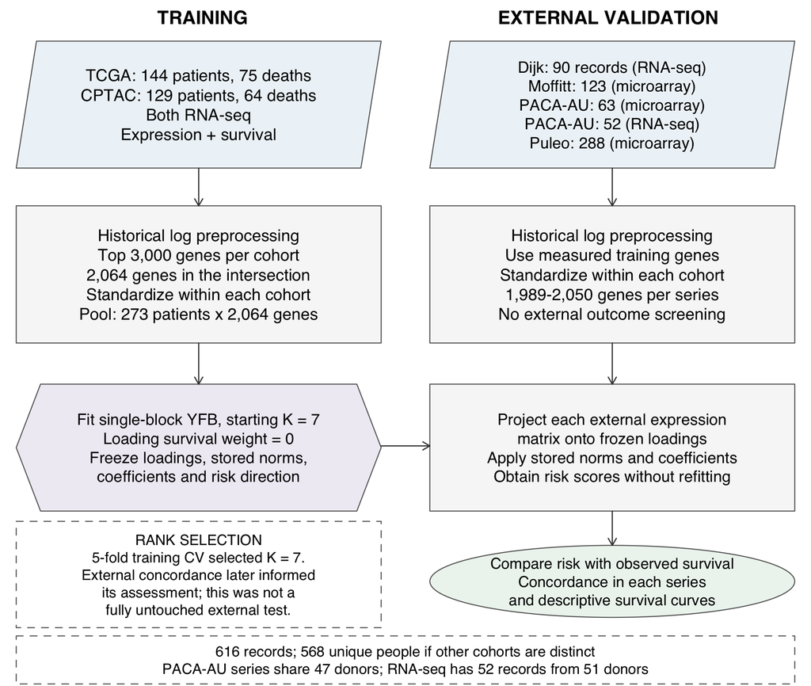

Figure 1: Single-modality real-data workflow for the frozen expression benchmark. Shapes denote cohort data (parallelograms), preprocessing/scoring (rectangles), fitted models (hexagons) and evaluation (ellipses); dashed boxes give context. TCGA and CPTAC supply 273 training patients (139 deaths); screening retains 2,064 shared genes. Five external dataset series supply 616 records, with repeated PACA-AU donors as indicated. External molecular data are preprocessed within cohort, then projected using frozen training parameters; survival outcomes evaluate the resulting scores. Starting rank 7 was informed by training cross-validation and subsequently assessed using external concordance, so the historical external evaluations were not wholly untouched by model-development decisions. Historical preprocessing includes the repeated log steps described in Section 1.4; the acquisition history remains incompletely documented. The evaluated loading update uses no survival information. TCGA, The Cancer Genome Atlas; CPTAC, Clinical Proteomic Tumor Analysis Consortium; PACA-AU, ICGC’s Australian pancreatic cancer project; YFB, the expression-projection Cox model; RNA-seq, RNA sequencing.

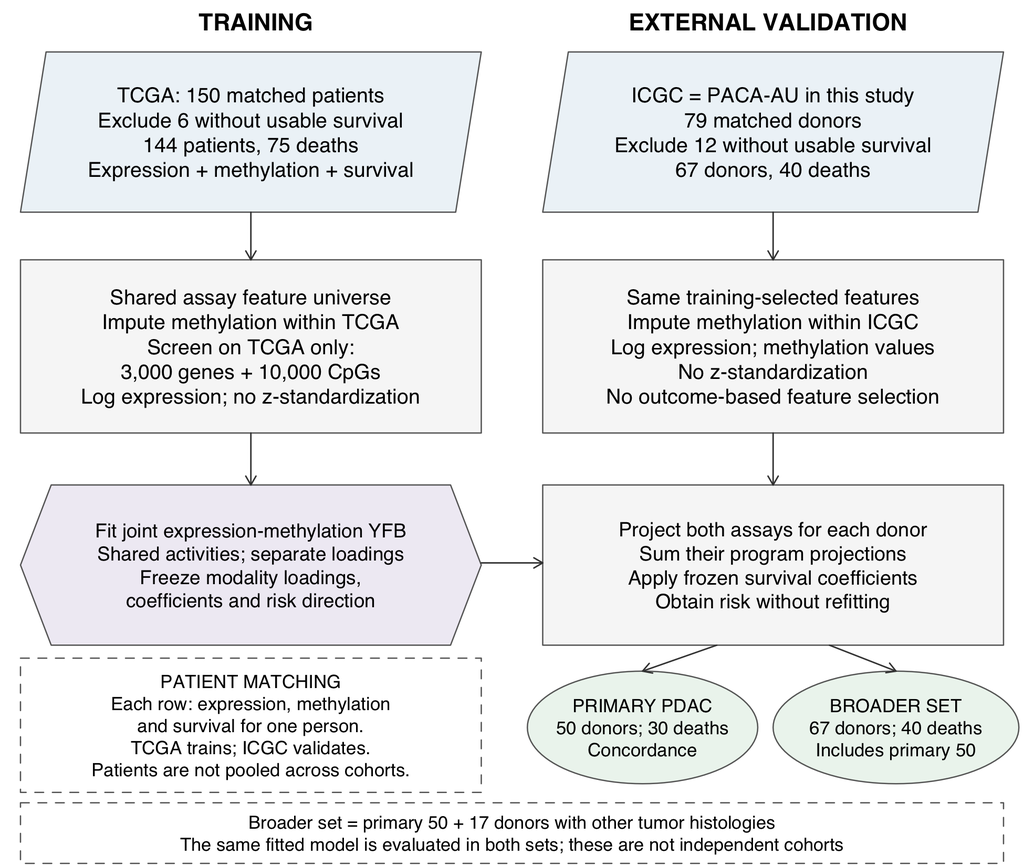

Figure 2: Multimodal real-data workflow for the evaluated joint expression-methylation model. Usable survival requires a positive observed time and a valid event indicator: six of 150 matched TCGA patients and 12 of 79 matched ICGC donors are excluded. Shared assay availability defines the feature universe; TCGA alone ranks and selects 3,000 genes and 10,000 CpG sites. Methylation is imputed separately within each cohort. Both validation populations use the same frozen modality loadings and survival coefficients, with no model refitting. The primary ICGC set has 50 primary-PDAC donors (30 deaths); the sensitivity set includes these same donors plus 17 with other histologies (67 donors, 40 deaths). The evaluated joint fit did not meet its convergence criterion. TCGA, The Cancer Genome Atlas; ICGC, International Cancer Genome Consortium; PACA-AU, its Australian pancreatic cancer project; PDAC, pancreatic ductal adenocarcinoma; CpG, cytosine–guanine methylation site; YFB, the joint molecular-projection Cox model.

In the multimodal setting, matching means that both assays and survival belong to the same patient within a cohort (Figure 2). TCGA supplies all model-training patients. The primary validation population is the 50 ICGC donors with primary PDAC; the broader 67-donor analysis adds other histologies and evaluates the same fitted model. It is a population sensitivity check, not another independent validation cohort. Keeping the primary population restricted to primary PDAC preserves the study’s target population. The primary analysis therefore includes 194 people across training and validation, but only the 144 TCGA patients estimate the model.

## 2.2 Simulation designs

**Single-modality model, two cohorts.** Each simulated dataset has two cohorts of 150 patients and 1,000 genes. True loading columns are the absolute values of loadings from an unsupervised empirical-Bayes matrix factorization (EBMF) of the real training data, scaled to amplitude 12; feature noise precisions are drawn from Gamma(2, 2). Survival times follow a Weibull proportional-hazards model whose predictor is $\sum_k L_{ik}\beta_k$ over the shared programs (coefficients recycled from $1.5, -1.2, 0.8, -0.5$), with censoring calibrated to 30%. Cohort-specific programs have zero loadings outside their cohort and no survival effect. Three scenarios vary the structure: all shared (six shared programs), hybrid (two shared and two cohort-specific programs per cohort), and nothing shared (three cohort-specific programs per cohort and no prognostic program). Each dataset is split 75/25 into training and test patients, stratified by event status, giving 75 test patients. Two arms are fitted at starting ranks 2, 3, 4, 6, 12 and 20 with 15 datasets per setting (540 fits): the single-modality model with the evaluated settings, and a two-step arm consisting of a nonnegative EBMF (R package flashier, at most $K_{\mathrm{init}}$ factors, with backfitting) followed by an unpenalized Cox model on least-squares projection scores. The data-generating predictor uses the latent activities $L$, whereas both arms predict from projections.

**Multimodal model.** Each dataset has 120 training and 120 validation patients, 50 expression and 50 methylation features, and three true programs. Survival follows a Weibull model with predictor $\sum_m Y_m F_m \beta$, matching the model’s predictor. Three scenarios set $\beta$: two prognostic programs ($0.70, 0.35, 0$), one adverse and one protective program ($0.70, -0.70, 0$), and a low-variance prognostic program whose activities are scaled by 0.15 ($\beta = 0, 0, 1.10$). Feature noise precisions are drawn from Gamma(2, 2), and each feature’s noise standard deviation (SD) is multiplied by 1 (higher noise) or 0.25 (lower noise). Each feature is shifted by four noise SDs so that the data are nonnegative and the base model without intercepts can also be fitted. Starting ranks are 3 to 10 and 15, with three datasets per setting. The same three datasets per scenario/noise combination are refitted at each of the nine starting ranks; 27 fits per cell therefore represent three independent datasets, not 27. Three variants are fitted to every dataset: a base model without feature intercepts or factor removal (nonnegative loadings, moment-based prior updates), the evaluated framework (Algorithm 2, Appendix B), and the same framework with the variance-penalized survival term in the removal score. The sweep contains 486 fits, 162 per variant.

## 2.3 Comparators

**Relationship to DeSurv.** DeSurv (Young et al. 2026) couples nonnegative matrix factorization to a Cox model so that survival guides the gene programs during discovery. Our proposed distinction is empirical-Bayes estimation of program distributions and uncertainty, with a shared-activity extension for matched modalities. Projection-based prediction is common to both approaches; it is not a unique contribution here. A predictive head-to-head using the authors’ current DeSurv package remains deferred. Gene-list correspondence below is biological context, not evidence of predictive superiority.

**Principal single-modality comparator.** An unsupervised EBMF (R package flashier (Wang and Stephens 2021; Willwerscheid et al. 2023); signed point-normal priors, gene-specific variances, greedy fitting with backfitting, at most 40 factors) of the same $273 \times 2{,}064$ training matrix, followed by a Cox model with a least absolute shrinkage and selection operator (LASSO) penalty on the normalized projection scores, with the penalty chosen by cross-validation (R package glmnet (Simon et al. 2011)). Forty is the greedy factor cap, not a rank selected by a parallel CV procedure. The factor cap was not informed by the benchmark model; 15 of the 40 factors received nonzero coefficients. Held-out patients are scored with the frozen loadings and coefficients.

**Supporting single-modality comparators.** A rank-matched two-step model (7 factors, unpenalized Cox) and a 20-factor two-step model with unpenalized Cox. Matching the rank gives the two-step model the supervised model’s choice of complexity, and the 20-factor model is not regularized, so neither is the principal comparison.

**Multimodal comparators.** On the matched cohorts, the same framework fitted to expression alone isolates the contribution of methylation. Four further arms are reported: the base multimodal model without feature intercepts or factor removal (nonnegative loadings, moment-based prior updates); a single-block fit of the model of Section 1.2 to unstandardized log2 TCGA expression (at most 100 sweeps, scored with its own fixed projections), and two-step EBMF followed by unpenalized Cox on expression alone or on stacked expression and methylation.

## 2.4 Performance metrics and uncertainty

External performance is Harrell’s concordance index (C) (Harrell et al. 1982), with higher values indicating better discrimination and the risk direction fixed from training. Historical confidence intervals (CIs) use percentile bootstrap resampling (Efron and Tibshirani 1993), with $B = 2{,}000$ resamples for the single-modality comparisons and $B = 1{,}000$ for the multimodal comparisons. Single-modality resampling treats cohort records as independent; multimodal resampling uses unique donors. Differences use the same resamples for both models. The single-modality intervals and pooled log-rank p-values do not account for repeated PACA-AU donors, including one repeated donor within its RNA-seq series. Cohort stratification does not remove this dependence. We retain the saved values as historical summaries and do not use them to establish statistical superiority or calibrated pooled significance. Donor-aware inference requires a separately specified analysis. All intervals hold the fitted models fixed and exclude training uncertainty.

Three summaries of the single-modality comparison are not interchangeable. The **mean external C** averages five series-specific C-indices. The **concatenated difference**, used for the principal and rank-matched comparisons, computes one C-index per model over all 616 cohort records, so comparable pairs can cross cohorts. The **inverse-variance pooled difference**, used for the 20-factor comparator, combines per-cohort paired differences. None is an equivalence or non-inferiority test.

Simulation summaries are means over fits, with independent dataset replication distinguished from repeated fits at different starting ranks. In the single-modality simulation, test-set concordance is the outcome-oriented $\max(C, 1-C)$, which is biased upward when there is no signal: in the nothing-shared scenario both arms score about 0.54. In the multimodal simulation, validation concordance uses the training-fixed direction. A true program counts as recovered when its absolute correlation with its independently best-matching estimated loading column is at least 0.7. This historical matching is not constrained to be one-to-one: multiple true programs may select the same estimate. In the multimodal simulation, correct-sign recovery additionally requires the matched estimate to be survival-active and its coefficient sign to agree with the true coefficient; the loading match uses absolute correlation, without a subsequent sign-alignment rule.

## 2.5 Feature-count sensitivity

We varied nested feature sets at fixed $K=7$, retaining the single-modality settings with $\alpha_F=0$ and fitting each count from a cold start. Screening by the existing cohort-specific ranks yielded 2,064, 5,001, 10,000 and all 17,900 shared gene identifiers across the 273 training patients. Each count had one full-training fit and the same five event-stratified training folds. Imputation, screening and cohort standardization preceded fold splitting, so the reported concordance is conditional cross-validation (CV), not an evaluation of the entire preprocessing pipeline. It is not directly comparable to external concordance. The reported SE is a descriptive standard error across five fold-specific C values; overlapping training sets mean the folds are not independent replications. Larger-set factors were paired to baseline factors by greedy, non-reused absolute correlations of training activities; signed loading correlations were then computed on common features. Constant factors remained undefined or unmatched. This descriptive matching does not establish unique or identical programs.

A separate methylation-only sensitivity used the multimodal framework with the original priors, working approximation, intercept and precision updates, $K=7$ and removal disabled. The planned nested counts were 10,000, 25,000, 50,000, 100,000 and all 305,352 eligible CpGs. The original whole-universe imputation was retained before screening, and the original 10,000-probe values and ranks reproduced exactly. Count expansion did not introduce a mean or variability filter. No external outcome selected a feature count, filter or numerical remedy.

## 2.6 Biological characterization

The program labels in Section 4 come from the following analyses of the evaluated single-modality fit and of the starting-rank-7 multimodal fit.

- **Ranked enrichment.** For each single-modality program, the 2,064 selected genes were ranked by their nonnegative posterior-mean loadings and tested against predefined gene sets with the fgsea algorithm (Korotkevich et al. 2021) for ranked gene-set enrichment (one-sided toward high loadings; set sizes 10–500). Collections were Hallmark (Liberzon et al. 2015), Reactome (Milacic et al. 2024), the Kyoto Encyclopedia of Genes and Genomes (KEGG) (Kanehisa and Goto 2000), Gene Ontology biological process (GO-BP) (Ashburner et al. 2000), and a PDAC collection of the Moffitt and Bailey subtype lists and the three DeSurv factor gene lists. The normalized enrichment score (NES) compares a set’s running-sum statistic with its permutation distribution; leading-edge genes are the set members ranked before the running-sum maximum. P-values were adjusted by the Benjamini–Hochberg (BH) method (Benjamini and Hochberg 1995) within each program and collection, and sets are reported at adjusted $p < 0.10$. Over-representation analysis (ORA) of the top 50, 100 and 150 genes against the selected-gene background checked dependence on the cutoff. These analyses show which predefined sets are concentrated among a program’s highest-loading genes.
- **Subtype concordance and gene-list overlap.** Training activities $\bar L$ in TCGA ($n = 144$) were compared with the basal-like probability and calls of PurIST (Rashid et al. 2020), a single-sample PDAC subtype classifier (Spearman correlation; Kruskal–Wallis test). The top 270 genes by loading were compared with the DeSurv factor lists, both restricted to the shared gene background (Jaccard similarity; hypergeometric test). P-values are unadjusted.
- **External signature association.** For a selected set, the signature score is the mean within-cohort standardized expression of its leading-edge genes. A univariable Cox hazard ratio (HR) per unit of signature score was estimated in each external cohort. For the two genomics-only programs, the set was chosen after excluding the whole PDAC collection, a choice made after the first signature check for one of them scored a classical-tumor list. Signature scores are distinct from the frozen program projections used for survival curves, which group patients by within-cohort tertile and use historical cohort-stratified log-rank tests when series are pooled. Their p-values do not adjust for repeated donors and remain descriptive.
- **Multimodal programs.** Labels come from a manual reading of each program’s eight highest positive and six most negative expression loadings; no enrichment test or CpG annotation was performed. Each program’s share of a modality’s fitted signal is $\lVert\bar L_{\cdot k}\rVert^2\lVert\bar F_{mk}\rVert^2$ divided by the sum of these rank-one squared norms within that modality. Correspondence with reference fits is the absolute Pearson correlation of loading columns over shared genes. Fourteen univariable Cox models (7 programs × 2 cohorts) give the HR per one within-cohort SD of the joint projection, without adjustment for multiplicity.

These analyses share inputs and are not independent validations. The PDAC collection and the gene-list overlap both use the DeSurv lists, and the selected gene universe was screened with DeSurv’s rule. The subtype check uses training activities in the cohort that trained the model. Multiplicity is controlled within each program and collection, not across them. The external control for the genomics-only programs was designed after an earlier result. The methods were chosen from those available, and whether they are the best tools for these questions has not been assessed.

# 3 Results

## 3.1 Single-modality simulation

At starting ranks at or above the true rank (6, 12 and 20), the model’s mean shared-program recovery was 97%–100% and its cohort-specific recovery 93%–100% (Table 3; rank 12 gave 0.98 and 1.00). Over-specifying the rank changed little. The two-step arm recovered fewer programs (73%–89% of shared and 70%–83% of specific programs) and did not change beyond rank 6, because its greedy factorization stopped adding factors. The model’s test concordance exceeded the two-step arm’s by 0.10–0.16 in the hybrid scenario from starting rank 3 upward and by about 0.02 in the all-shared scenario from rank 6 (Figure 3). At ranks 3 and 4 in the all-shared scenario the two-step arm was better by 0.02–0.03. With nothing prognostic, both arms were near the outcome-oriented null of 0.54. In the evaluated configuration the loading updates do not use survival, so these differences arise from the fitting procedure (initialization and coordinate updates versus greedy factorization) and the coefficient prior, not from survival-guided loadings. Among programs without a survival effect, 22%–35% were classified survival-active in the hybrid scenario at starting ranks 4–20, and 6%–10% with nothing shared.

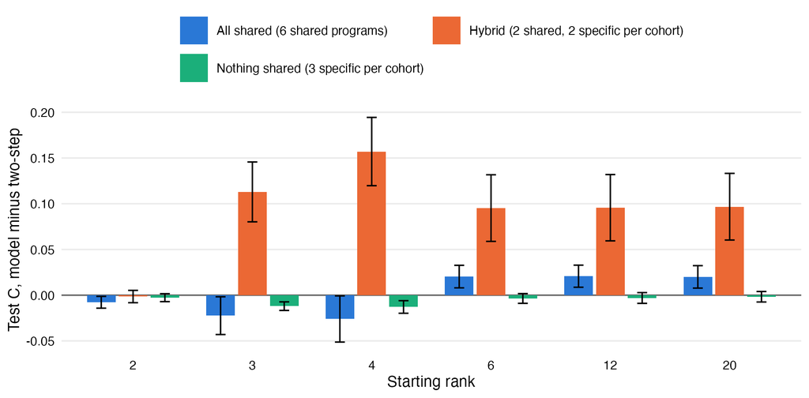

Figure 3: Difference in test concordance between the single-modality model and the two-step arm in the two-cohort simulation, by scenario and starting rank (true rank 6). Bars are means over 15 simulated datasets, each scored on the same 75 test patients for both arms; error bars are $\pm 1$ standard error of the mean paired difference. C is Harrell’s concordance index (higher is better), computed in the outcome-oriented form $\max(C, 1-C)$. The two-step arm is nonnegative empirical-Bayes matrix factorization followed by unpenalized Cox regression on projection scores. All shared: six shared prognostic programs. Hybrid: two shared prognostic and two cohort-specific non-prognostic programs per cohort. Nothing shared: three cohort-specific non-prognostic programs per cohort.

Table 3: Program recovery and survival activity in the two-cohort simulation (true rank 6; means over 15 datasets of 300 patients, 225 for training). True shared and cohort-specific programs per scenario: all shared, 6 and 0; hybrid, 2 and 2 per cohort; nothing shared, 0 and 3 per cohort. “Recovered” is the fraction of true programs whose best-matching estimated loading column has absolute correlation at least 0.7. “Active” is the fraction of true prognostic (or non-prognostic) programs whose matched estimate has $|\bar{\tilde\beta}_k| > 0.001$. The two-step arm is nonnegative empirical-Bayes matrix factorization followed by unpenalized Cox regression. Dashes mark quantities undefined in a scenario. Rows show starting ranks 6 and 20. At rank 12 the model’s shared recovery was 0.98 (all shared) and 1.00 (hybrid); at rank 4, below the true rank, it was 0.59 and 0.80, against 0.54 and 0.27 for the two-step arm. $\bar{\tilde\beta}_k$ is the posterior-mean survival coefficient of the single-modality model.

| Scenario | Starting rank | Shared recovered (model / two-step) | Specific recovered (model / two-step) | Prognostic active (model) | Non-prognostic active (model) |
| --- | --- | --- | --- | --- | --- |
| All shared | 6 | 1.00 / 0.89 | – | 1.00 | – |
| All shared | 20 | 1.00 / 0.89 | – | 0.93 | – |
| Hybrid | 6 | 1.00 / 0.73 | 0.93 / 0.83 | 1.00 | 0.35 |
| Hybrid | 20 | 0.97 / 0.73 | 0.98 / 0.83 | 1.00 | 0.27 |
| Nothing shared | 6 | – | 0.96 / 0.70 | – | 0.10 |
| Nothing shared | 20 | – | 1.00 / 0.70 | – | 0.10 |

In a separate ten-dataset simulation with cohort-specific coefficients for a program prognostic in only one cohort, the coefficient was larger in the cohort with the effect in 15 of 20 cohort-by-dataset cases at starting rank 6 and 17 of 20 at rank 12; one dataset diverged.

## 3.2 Single-modality external validation

The frozen model’s mean external C was 0.627 (from 0.549 in Moffitt to 0.657 in PACA-AU RNA-seq) and the principal comparator’s 0.601 (Table 4). Over the 616 concatenated cohort records, the C-indices were 0.6285 and 0.6026, a difference of 0.026 (95% CI 0.0002 to 0.050), a small historical difference whose interval does not account for repeated donors. It does not establish superiority under donor-aware inference. The rank-matched comparator, which was better in both PACA-AU cohorts, gave a difference of 0.011 ($-0.013$ to $0.033$). The 20-factor unpenalized comparator gave an inverse-variance pooled difference of 0.042 (0.013 to 0.071).

Table 4: External concordance of the frozen single-modality model and three two-step comparators (factorization, then Cox regression on projection scores) in five external PDAC dataset series. C is Harrell’s concordance index (higher is better), with every model’s risk direction fixed from training. The model’s historical CIs use independent-record percentile bootstrap resampling ($B = 2{,}000$); repeated donors are not clustered. The 40-factor comparator with a LASSO-penalized Cox model is the principal comparison; the rank-matched and 20-factor unpenalized comparators are supporting. $^a$Difference of C-indices computed once over the 616 concatenated cohort records; bootstrap over records, both models on the same resamples. $^b$Inverse-variance pooled series-specific paired differences; dependence between overlapping series is not modeled. The 616 records and 414 death records include repeated donors; these intervals are historical and do not establish donor-aware significance. PDAC, pancreatic ductal adenocarcinoma; CI, confidence interval; LASSO, least absolute shrinkage and selection operator; PACA-AU, Australian pancreatic cancer cohort of the International Cancer Genome Consortium; RNA-seq, RNA sequencing.

| Dataset series | Records | Death records | Model C (95% CI) | Two-step, 40 factors, LASSO | Two-step, 7 factors | Two-step, 20 factors |
| --- | --- | --- | --- | --- | --- | --- |
| Dijk | 90 | 81 | 0.634 (0.555, 0.708) | 0.600 | 0.577 | 0.592 |
| Moffitt | 123 | 83 | 0.549 (0.467, 0.625) | 0.560 | 0.541 | 0.541 |
| PACA-AU microarray | 63 | 38 | 0.648 (0.553, 0.747) | 0.623 | 0.665 | 0.597 |
| PACA-AU RNA-seq | 52 | 31 | 0.657 (0.544, 0.772) | 0.603 | 0.690 | 0.573 |
| Puleo | 288 | 181 | 0.645 (0.599, 0.688) | 0.618 | 0.643 | 0.602 |
| Mean C across five series; summed records | 616 | 414 | 0.627 | 0.601 | 0.623 | 0.581 |
| Difference, model minus comparator (95% CI) |  |  |  | 0.026 (0.0002, 0.050)$^a$ | 0.011 ($-0.013$, 0.033)$^a$ | 0.042 (0.013, 0.071)$^b$ |

Survival curves by within-cohort tertile of the frozen risk score generally favored the low-risk tertile (Figure 4). Historical log-rank p-values were below 0.05 in three of five series: Dijk ($p = 0.00046$), PACA-AU RNA-seq ($p = 0.021$) and Puleo ($p < 0.0001$), but not PACA-AU microarray ($p = 0.075$) or Moffitt ($p = 0.17$). Tertiles are descriptive within-cohort groups, not clinical cutoffs. The PACA-AU RNA-seq p-value also treats its two records from one donor as independent; all displayed p-values are unadjusted descriptive results.

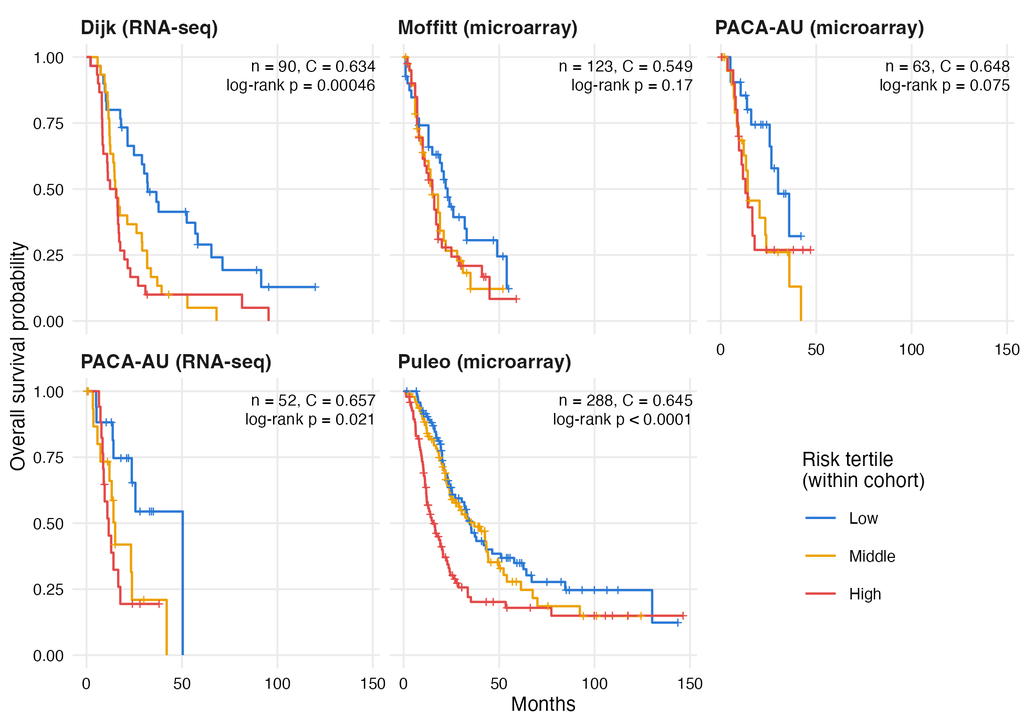

Figure 4: Overall survival by within-cohort tertile of the frozen single-modality risk score in five external PDAC dataset series ($n = 616$ cohort records, 414 death records, including repeated donors). The risk score is $-\eta$, a direction fixed from training. Tertiles are formed within each cohort. Lines are Kaplan–Meier estimates; crosses mark censored patients. Each panel gives its record count, the concordance index C (Harrell’s; higher is better), and the historical log-rank test across the three tertiles. These p-values are unadjusted and do not account for repeated donors; they are descriptive. Time is in months. PDAC, pancreatic ductal adenocarcinoma; PACA-AU, Australian pancreatic cancer cohort of the International Cancer Genome Consortium; RNA-seq, RNA sequencing.

## 3.3 Starting rank and factor classification

At starting rank 7 the evaluated fit has three inactive factors, two genomics-only programs (5 and 6), and two survival-active programs (3 and 7); the retained programs each explain 1.9%–3.0% of the training variance. In the sweep over starting ranks (Table 5), the monitoring statistic and the Bayesian information criterion (BIC) both favor $K_{\mathrm{init}} = 3$, the cross-validated survival log partial likelihood is highest at 19, and the joint log-likelihood (not shown) keeps rising to 15. External concordance is below 0.60 up to starting rank 6 and between 0.626 and 0.628 at every rank from 7 to 20 except 11 (0.600) and 13 (0.539). The number of survival-active programs is 1 at starting ranks 2–4 and 2 or 3 from rank 5 upward. Starting rank 7 is the smallest rank on the external-concordance plateau and the rank selected by training cross-validation.

Table 5: Single-modality model at selected starting ranks $K_{\mathrm{init}}$ from a sweep over 2 to 20 (training $n = 273$ patients, $p = 2{,}064$ genes; every fit met the stopping rule). Arrows give the preferred direction of each criterion. Survival-active: $|\bar{\tilde\beta}_k| > 0.001$. Genomics-only: not survival-active and proportion of variance explained (PVE) above 1%. $J$ is the monitoring statistic at the final sweep, not an evidence lower bound. BIC, Bayesian information criterion from the joint log-likelihood with $K_{\mathrm{init}}(n + p + 1)$ parameters. CV log PL, five-fold cross-validated (CV) Cox log partial likelihood (PL) per death. C, Harrell’s concordance index averaged over the five held-out cohorts; it informed the choice of starting rank.

| Starting rank | Survival-active | Genomics-only | Monitoring statistic $J$ ($\uparrow$) | BIC ($\downarrow$) | CV log PL per death ($\uparrow$) | Mean external C ($\uparrow$) |
| --- | --- | --- | --- | --- | --- | --- |
| 3 | 1 | 2 | $-806{,}783$ | 1,575,641 | $-3.222$ | 0.594 |
| 5 | 3 | 1 | $-808{,}550$ | 1,581,604 | $-3.205$ | 0.596 |
| 7 | 2 | 2 | $-810{,}687$ | 1,614,080 | $-3.230$ | 0.627 |
| 9 | 2 | 3 | $-810{,}568$ | 1,623,226 | $-3.212$ | 0.627 |
| 10 | 2 | 3 | $-814{,}091$ | 1,636,335 | $-3.194$ | 0.628 |
| 12 | 2 | 3 | $-820{,}757$ | 1,662,571 | $-3.176$ | 0.627 |
| 15 | 2 | 3 | $-826{,}829$ | 1,697,684 | $-3.195$ | 0.627 |
| 20 | 2 | 3 | $-847{,}947$ | 1,767,490 | $-3.183$ | 0.627 |

At starting rank 7 the classification (two survival-active, two genomics-only) was unchanged for coefficient thresholds from $10^{-4}$ to $10^{-2}$ combined with PVE thresholds from 0.1% to 2%; a PVE threshold of 5% removes both genomics-only programs.

## 3.4 Multimodal simulation

With factor removal, the final number of programs depends much less on the starting rank (Figure 5); the base model has no removal step, so its final rank equals the starting rank in all 162 fits. At lower noise, the evaluated framework returned a mean of 3.2–3.3 programs in the two scenarios with high-variance prognostic programs and 2.5 in the low-variance scenario, averaged over starting ranks, and the means were close to constant from starting rank 4 upward. At higher noise it returned fewer than three programs on average (1.7–2.0), and the final rank rose with the starting rank, from 1 at starting rank 3 to 2.3–3.3 at ranks 10 and 15. All 162 fits of the evaluated framework met the convergence criterion, against 27 of 162 for the base model.

At lower noise the framework recovered all three programs in the two-prognostic scenario and 2.96 of 3 in the adverse-and-protective scenario, found 87% of prognostic programs with the correct sign, and had validation C of 0.79–0.80 (Table 6). In the low-variance scenario it recovered about two programs, found the low-variance prognostic program in none of the 27 fits, and classified 1.26 other programs per fit as survival-active, attributing survival to high-variance programs; validation C was 0.63. At higher noise, recovery was lower (0.93–1.33 programs), but the low-variance prognostic program was found in 52% of fits (48% with the correct sign). In that setting every true program is weak, so the result does not show recovery of a low-variance program alongside strong ones. The variance-penalized survival term changed no summary in Table 6 by more than 0.04. Each cell averages 27 fits from three simulated datasets per setting, which limits precision.

Table 6: Multimodal simulation (120 training and 120 validation patients, 50 expression and 50 methylation features, true rank 3). Noise multiplies every feature’s noise SD by 0.25 (lower) or 1 (higher); feature precisions are drawn from Gamma(2, 2). Values are means over 27 fits per cell (starting ranks 3–10 and 15, three simulated datasets each) for the evaluated framework, with the base model without intercepts or factor removal in parentheses. “Recovered”: absolute loading correlation at least 0.7 with the best-matching estimate. “Prognostic found, correct sign”: fraction of true prognostic programs matched by a survival-active estimate (posterior mean at least 1.96 posterior SDs from zero) with the correct coefficient sign. “False survival-active”: survival-active estimates per fit not matched to a true prognostic program. Validation C: Harrell’s concordance with the training-fixed direction. “Converged”: fraction meeting the stopping rule within 500 sweeps. No uncertainty intervals are given. SD, standard deviation. The evaluated framework (Algorithm 2, Appendix B) has feature intercepts, signed point-Laplace loadings, marginal-likelihood prior estimation and factor removal.

| Noise | Scenario | Final rank | Programs recovered (of 3) | Prognostic found, correct sign | False survival-active | Validation C | Converged |
| --- | --- | --- | --- | --- | --- | --- | --- |
| Lower | Two prognostic | 3.26 | 3.00 (2.74) | 0.87 | 0.67 | 0.80 | 1.00 (0.07) |
| Lower | Adverse and protective | 3.22 | 2.96 (2.78) | 0.87 | 0.59 | 0.79 | 1.00 (0.37) |
| Lower | Low-variance prognostic | 2.48 | 1.96 (2.00) | 0.00 | 1.26 | 0.63 | 1.00 (0.19) |
| Higher | Two prognostic | 1.74 | 1.19 (0.11) | 0.57 | 0.44 | 0.79 | 1.00 (0.07) |
| Higher | Adverse and protective | 1.96 | 1.33 (0.59) | 0.67 | 0.52 | 0.80 | 1.00 (0.22) |
| Higher | Low-variance prognostic | 1.96 | 0.93 (0.15) | 0.48 | 1.15 | 0.81 | 1.00 (0.07) |

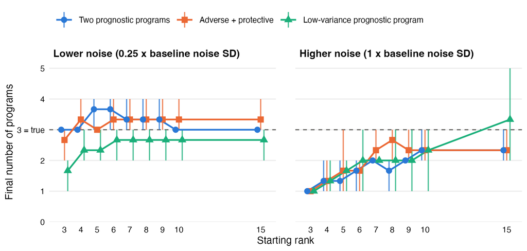

Figure 5: Final number of programs against starting rank in the multimodal simulation (true rank 3, dashed line) for the evaluated framework with factor removal. Each point is the mean over three simulated datasets, and vertical bars span the three values (not confidence intervals); points are offset horizontally for legibility. Noise multiplies every feature’s noise SD by 0.25 or 1. Each dataset has 120 training patients and 50 expression and 50 methylation features. The base model has no removal step, so its final rank equals the starting rank and is not drawn. SD, standard deviation.

## 3.5 Multimodal real-data validation

On the 50 primary-PDAC ICGC donors at starting rank 7, the joint expression-and-methylation fit had $C = 0.685$ (0.579, 0.779) and the expression-only fit of the same framework $C = 0.676$ (0.569, 0.770) (Table 7). Neither fit met the convergence criterion within 500 sweeps. The descriptive difference is 0.0095; a paired difference interval was not calculated, and the overlapping marginal intervals are not a test of increment; similar observed concordance is not evidence of equivalence. On all 67 donors the order reversed (0.639 and 0.653). The two-step comparators had concordance below 0.53, and the base joint model without intercepts or factor removal 0.453.

Table 7: Concordance on matched ICGC donors at starting rank 7 (30 deaths among the 50 primary-PDAC donors, 40 among all 67). Every model was trained on the 144 TCGA patients (75 deaths) with expression (Expr.) from 3,000 genes and, where used, methylation (meth.) at 10,000 CpG sites. C is Harrell’s concordance index with the risk direction fixed from training; intervals are percentile bootstrap 95% CIs over patients ($B = 1{,}000$). The base multimodal model has no intercepts or factor removal; the single-block model is a fit of the model of Section 1.2 to unstandardized log2 expression with at most 100 sweeps; two-step is empirical-Bayes matrix factorization followed by unpenalized Cox regression. None of the three multimodal fits met the stopping rule (relative change below $10^{-4}$) within 500 sweeps. TCGA, The Cancer Genome Atlas; ICGC, International Cancer Genome Consortium; PDAC, pancreatic ductal adenocarcinoma; CI, confidence interval; CpG, cytosine–guanine methylation site.

| Model | Data | ICGC primary PDAC ($n = 50$) | ICGC all donors ($n = 67$) | TCGA training |
| --- | --- | --- | --- | --- |
| Multimodal framework | Expr. + meth. | 0.685 (0.579, 0.779) | 0.639 (0.547, 0.734) | 0.638 |
| Multimodal framework | Expr. | 0.676 (0.569, 0.770) | 0.653 (0.568, 0.744) | 0.644 |
| Base multimodal model | Expr. + meth. | 0.453 (0.319, 0.599) | 0.442 (0.335, 0.562) | 0.597 |
| Single-block model | Expr. | 0.491 (0.364, 0.633) | 0.480 (0.369, 0.581) | 0.594 |
| Two-step, then Cox | Expr. | 0.525 (0.399, 0.651) | 0.527 (0.425, 0.641) | 0.670 |
| Two-step, then Cox | Expr. + meth. | 0.424 (0.286, 0.567) | 0.418 (0.310, 0.531) | 0.579 |

No factor was removed at any starting rank: the final rank equals the starting rank in all nine fits (Table 8). Only the fits at starting ranks 3 and 4 met the convergence criterion; the other seven stopped at the cap, and the removal check ran on those unconverged fits. Concordance on the 50 primary donors ranged from 0.500 at rank 5, where no program was survival-active and every patient received the same score (historically reported as C = 0.500, indicating no discrimination), to 0.685 at rank 7; the median over the nine ranks was 0.572. The number of survival-active programs rose with the starting rank, from 0 to 11, while concordance did not. The constant-score value is preserved from the historical sweep; later prospective studies report undefined C as NA for such failures and must not be compared as if the conventions were identical. Rank 7 was chosen in advance as the single-modality default, but it is also the rank with the highest validation concordance in this sweep, so the rank-7 results are favorable relative to the other ranks. The reconstruction term of Equation 36 sums over $144 \times 13{,}000$ molecular values, whereas the survival term is a partial likelihood over 75 deaths, which motivates examining the relative contributions but does not alone establish their influence on deletion. In the saved capped joint fit, reconstruction, survival and cached KL components were approximately 610,423, -304 and 130,212. These terminal levels are distinct from candidate-deletion changes; they do not prove that survival is negligible in every removal decision. The coordinate-level loading audit in Appendix C addresses a different quantity.

Table 8: Joint multimodal fits of the evaluated framework at each starting rank (one fit per rank, trained on 144 TCGA patients with 75 deaths). Final rank: factors remaining after the removal check. Survival-active: posterior mean at least 1.96 posterior SDs from zero. Converged: met the stopping rule within 500 sweeps. C: Harrell’s concordance index with the training-fixed direction on the ICGC primary-PDAC donors ($n = 50$) or all ICGC donors ($n = 67$); no intervals are shown. Validation sets: 50 primary-PDAC donors (30 deaths) and all 67 donors (40 deaths). TCGA, The Cancer Genome Atlas; ICGC, International Cancer Genome Consortium; PDAC, pancreatic ductal adenocarcinoma; SD, standard deviation.

| Starting rank | 3 | 4 | 5 | 6 | 7 | 8 | 9 | 10 | 15 |
| --- | --- | --- | --- | --- | --- | --- | --- | --- | --- |
| Final rank | 3 | 4 | 5 | 6 | 7 | 8 | 9 | 10 | 15 |
| Survival-active | 0 | 1 | 0 | 0 | 1 | 2 | 1 | 3 | 11 |
| Converged | Yes | Yes | No | No | No | No | No | No | No |
| C, primary PDAC | 0.557 | 0.574 | 0.500 | 0.546 | 0.685 | 0.589 | 0.572 | 0.650 | 0.547 |
| C, all donors | 0.499 | 0.502 | 0.500 | 0.522 | 0.639 | 0.545 | 0.547 | 0.610 | 0.532 |

## 3.6 Feature-count sensitivity

All 24 single-modality fits converged without warnings or errors. Conditional CV concordance did not increase consistently as features were added (Table 9). The largest set had mean C of 0.607 versus 0.608 for the current screened set; similar point estimates do not establish non-inferiority. Four, four, four and three programs were retained by the existing classification, respectively; every full fit had two operationally survival-active programs. No factor was deleted or refitted. The largest set included 240 constant standardized columns, kept under the existing preprocessing rule.

Table 9: Feature-count sensitivity of the single-modality model on 273 training patients, fixed $K=7$, $\alpha_F=0$ and cold starts. Each new row has five finite, converged CV folds; SE is the descriptive fold-based standard error of mean concordance, not an independent-replication uncertainty interval. Risk direction is fixed from training. The frozen benchmark is a saved fit, not a new CV estimate; its external mean C remains 0.627 and was not rescored. Retained counts classify programs without deletion and do not represent selected genes. CV, cross-validation; C, Harrell’s concordance index; SE, standard error.

| Fit | Shared genes | Training C | Conditional CV C (SE) | Retained |
| --- | --- | --- | --- | --- |
| Frozen benchmark | 2,064 | .656 | Not recomputed | 4 |
| Fresh screened fit | 2,064 | .656 | .6084 (.0462) | 4 |
| Expanded | 5,001 | .616 | .5773 (.0266) | 4 |
| Expanded | 10,000 | .617 | .6088 (.0397) | 4 |
| All shared | 17,900 | .619 | .6068 (.0186) | 3 |

Program agreement depends on the comparison. From 5,001 to 10,000 genes, all four nonconstant matched programs have common-gene loading correlations .960–.994 and activity correlations .933–.993; risk scores correlate .972. Thus this expansion preserves programs well. From 10,000 to all 17,900 genes, three defined pairs have loading correlations .737–.915 and risk correlation .667. Relative to the smaller 2,064-gene baseline, median signed loading correlations are .297/.333/.566 at 5,001/10,000/17,900 genes (four/four/three defined pairs), with risk correlations .655/.638/.505. Two baseline-to-5k/10k loading matches are strong and two weak; constant/unmatched factors have undefined correlations. Similar concordance therefore coexists with strong agreement over some expansions and less uniform agreement across the full range. The fresh screened fit reproduces the frozen loading/activity means to about $10^{-10}$ and risk correlation exceeds .999999; stored coefficient uncertainty differs because the historical fit discarded that variance. Dense loading means in retained nonzero columns do not validate gene-level selection or justify transferring the original biological labels to larger fits.

The methylation-only reference produced nonconstant risk but no credibly prognostic coefficient and reached the 500-sweep cap (Table 10). The 25,000-CpG fit failed before a fitted model could be saved. An identical-settings replay located the first invalid working inputs at outer sweep 6: finite predictors spanned about 5,734 units, global exponential shifting underflowed 143 of 144 weights to zero, and 17 risk-set denominators became zero. Projection means and variances were valid. A log-space evaluation of the same risk sums makes the working quantities finite at that captured predictor, with working weights summing to 75 deaths to numerical tolerance. This arithmetic correction does not change the likelihood or diagonal approximation. This identifies a numerical failure in the Cox working calculation alongside rapid predictor expansion; it does not show that more CpGs are intrinsically unsuitable, and numerical stabilization alone would not establish convergence.

Table 10: Full-training results on the same 144 TCGA patients, with saved benchmark rows labelled frozen. Dashes denote undefined values after numerical failure. Molecular inputs differ; these rows are contextual training comparisons, not matched CV estimates or estimates of incremental methylation benefit. Credible means $|E\beta|\ge1.96\,\mathrm{SD}(\beta)$ with positive posterior SD. No new external score was computed. Larger counts and methylation CV remain unrun. The stable-arithmetic row is unconverged; its high training C is not evidence of improved prediction. C, Harrell’s concordance index; TCGA, The Cancer Genome Atlas; CpG, cytosine–guanine methylation site; CV, cross-validation; SD, standard deviation.

| Fit | Genes | CpGs | C | Credible | Outcome |
| --- | --- | --- | --- | --- | --- |
| Frozen joint | 3,000 | 10,000 | .638 | 1 | 500-sweep cap |
| Frozen expression-only | 3,000 | 0 | .644 | 1 | 500-sweep cap |
| Methylation-only reference | 0 | 10,000 | .613 | 0 | 500-sweep cap |
| Methylation-only expansion, original arithmetic | 0 | 25,000 | — | — | Numerical failure |
| Same 25k case, stable arithmetic | 0 | 25,000 | .984 | 7 | 500-sweep cap |

Stable arithmetic repaired execution but did not produce a converged fit. The high training C, extreme predictor scale and unfinished larger-count/CV studies preclude a feature-count recommendation. Detailed numerical diagnostics, provisional count agreement, conditional loading-balance measurements and unadopted probe filters are retained in Appendix C.

## 3.7 Loading-prior consistency diagnostic

A saved-state replay identified a loading-prior refit that changes the prior without updating its cached KL penalty. A single opt-in fixed-posterior prior check reached the native monitor stopping rule in 10 sweeps versus a 300-sweep reference cap, but its output movement remained 0.01915 against a $10^{-4}$ tolerance and the monitor decreased three times. Local prior consistency therefore did not establish settled outputs, global ascent or an adopted remedy. Algebra, numerical checks and the complete failure record are retained in Appendix C.

# 4 Biological findings

## 4.1 Single-modality programs

The evaluated fit retains four programs: two survival-active (7 and 3) and two genomics-only (5 and 6). Their loadings were estimated without survival ($\alpha_F = 0$), so the labels describe dominant expression structure of the training data that survival then weights; they are not evidence of survival-guided discovery. Normalized enrichment scores for the cited sets are modest (1.05–1.29), and multiplicity is controlled only within each program and collection.

**Program 7: adverse, basal-like-associated expression.** Its highest loadings combine glycolytic genes (GAPDH, ENO1, TPI1, PGK1, LDHA) with integrin and receptor tyrosine kinase (RTK) genes (ITGA3, ITGB4, MET, CDCP1). Enriched sets include DeSurv’s basal-like list (adjusted $p = 0.0006$), the KEGG growth-factor RTK–phosphoinositide 3-kinase (PI3K) and RAS–extracellular signal-regulated kinase (ERK) pathways (adjusted $p = 0.001$), and the Bailey squamous list (adjusted $p = 0.03$). Training activities correlate with the PurIST basal-like probability ($\rho = 0.58$); the top genes overlap only DeSurv’s basal-like list (Jaccard 0.18); the basal-like signature has an HR above 1 in all five external cohorts (1.30–2.40 per unit of signature score, $p < 0.05$ in two); and projection tertiles separate external survival (Figure 6). The program corresponds to a factor of the unsupervised factorization of the same data ($r = 0.69$; next best 0.33).

**Program 3: protective, classical-associated expression.** The top genes are epithelial and secretory (CAPN5, LPCAT4, MLPH, SLC45A3, TJP3, GALNT6). The classical label rests mainly on subtype concordance ($\rho = -0.58$ with the basal-like probability) and on the classical signature’s HR below 1 in all five cohorts (0.42–0.88, $p < 0.05$ in three). The enrichment is less specific: DeSurv’s classical and basal-like lists are both enriched (adjusted $p = 0.017$ each), together with the Moffitt classical list and three integrin–focal adhesion kinase sets, and the top genes overlap both lists (Jaccard 0.13 and 0.10). Its unsupervised correspondence is less distinct ($r = -0.72$; next best 0.60).

**Program 5: genomics-only, stromal-associated expression.** Collagen and fibroblast genes dominate (COL1A2, COL3A1, COL5A2, THBS2, CDH11, SPARC). Its twelve enriched sets are led by the Hallmark epithelial–mesenchymal transition (EMT) set (adjusted $p = 0.0005$), DeSurv’s stromal-immune list and extracellular matrix (ECM) organization. Its top genes overlap only the stromal-immune list (Jaccard 0.18), it leans weakly basal ($\rho = 0.30$), and its EMT signature is not consistently prognostic externally (HR 0.73–1.50, $p < 0.05$ in one cohort).

**Program 6: genomics-only, immune-associated expression with a vascular component.** Lymphoid genes (IKZF1, AKNA, IL10RA, RCSD1, PREX1) are mixed with vascular and basement-membrane genes (APOLD1, COL14A1, TNXB, FBLN5, SLIT3, SPARCL1). Most of its 40 enriched sets are immune GO-BP terms, although the two smallest adjusted p-values belong to DeSurv’s classical and stromal-immune lists. It is uncorrelated with the PurIST axis ($\rho = -0.03$) but differs across PurIST calls (Kruskal–Wallis $p = 0.007$), a non-monotonic relation. Scored on its own immune set, it has no consistent external association (HR 0.53–1.39, none with $p < 0.05$).

Together, the four programs correspond to DeSurv’s three factors, with DeSurv’s combined stromal-immune factor divided between a stromal and an immune program. This is gene-list correspondence within a gene universe screened by DeSurv’s rule, not an independent replication of DeSurv and not a predictive comparison with it.

Adverse and protective labels follow the marginal association of each program’s projection with survival; the risk-scale coefficients of Section 1.2.1 agree in sign but are conditional on the other programs.

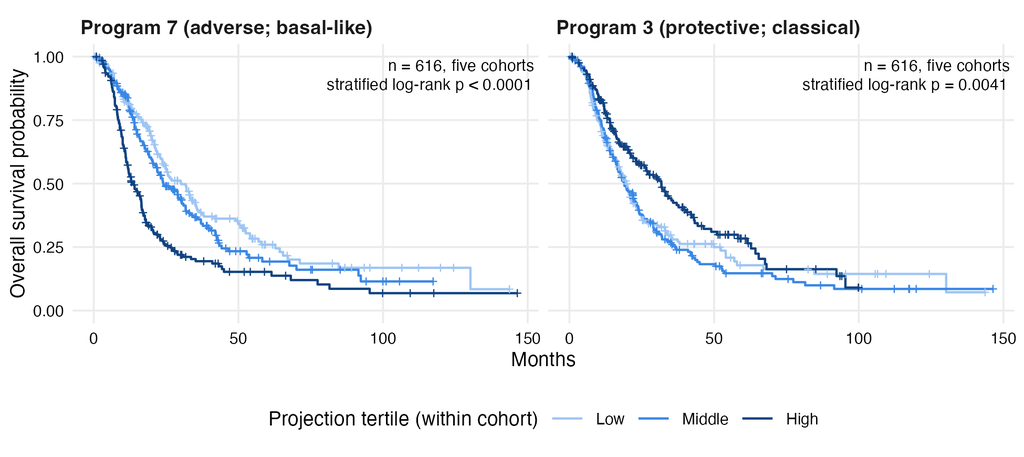

Figure 6: Overall survival by within-cohort tertile of the frozen Program 7 and Program 3 projection scores of the single-modality model, pooled over the five external PDAC dataset series ($n = 616$ cohort records, 414 death records, including repeated donors). Projection scores are the patient’s standardized expression projected onto the program’s loading column divided by its stored training norm; they are distinct from training activities and from signature scores. Lines are Kaplan–Meier estimates; crosses mark censored patients. P-values are historical cohort-stratified log-rank results, unadjusted for multiplicity or repeated donors. The curves describe the saved records; stratification does not make repeated observations independent, so pooled significance is not established. Time is in months. PDAC, pancreatic ductal adenocarcinoma.

## 4.2 Multimodal programs

The starting-rank-7 joint fit has seven programs (Table 11). Labels are provisional. They come from a manual reading of each program’s highest positive and most negative expression loadings, together with loading correlations to three reference fits. No enrichment test and no CpG annotation was performed. The correlations are absolute values, so they do not show whether a matched pair points in the same direction, and best matches chosen independently for each program need not form a one-to-one alignment; for example, both the immune and stromal programs have their best single-modality match in Program 6.

The one survival-active program (4) is the basal-like versus classical axis, with a marginal HR of 1.99 per SD of the joint projection in ICGC ($p = 0.00033$), and it corresponds to single-modality Program 7. The classical/gastric program (1) corresponds to single-modality Program 3 but is not survival-active. Three of the 14 marginal tests have $p < 0.05$ (Program 4 in both cohorts and Program 5 in TCGA), without correction for multiplicity. These exploratory joint-projection HRs differ from conditional survival coefficients and do not isolate a methylation-specific effect or demonstrate incremental methylation value.

Methylation-associated reconstruction structure appears in two ways (Figure 7). A methylation-only program accounts for 58.9% of the sum of program-wise rank-one squared norms within methylation and has no expression loading. The immune-associated program accounts for 20.9% of that same normalized rank-one total while being defined on the expression side by immune genes. Neither is survival-active, and neither has a marginal association with $p < 0.05$. Because cross-terms between programs are excluded, these shares are not additive proportions of variance, and they do not measure contributions to survival prediction.

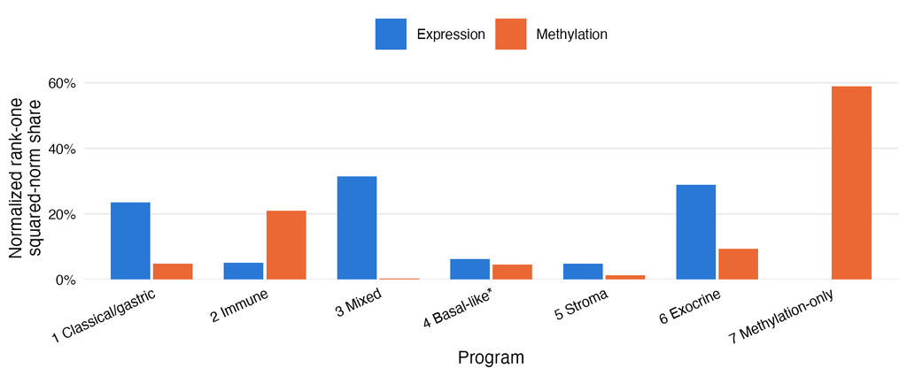

Figure 7: Normalized rank-one squared-norm share for each program within each modality of the starting-rank-7 joint multimodal fit (TCGA training, $n = 144$; 3,000 genes and 10,000 CpG sites). For modality $m$, the share of program $k$ is $\lVert\bar L_{\cdot k}\rVert^2\lVert\bar F_{mk}\rVert^2$ divided by the sum of these quantities over programs. The asterisk marks the survival-active program (posterior mean at least 1.96 posterior SDs from zero). Shares are neither additive variance explained nor survival contributions. TCGA, The Cancer Genome Atlas; CpG, cytosine–guanine methylation site; SD, standard deviation.

Table 11: Programs of the joint multimodal fit at starting rank 7 (TCGA training, $n = 144$). Genes are gene symbols with the largest positive (+) and negative ($-$) expression loadings. References, matched by the largest absolute Pearson correlation of loading columns over shared genes: SM, the single-modality model’s programs (1,781 shared genes; program number given when the match is a retained program); U, an unsupervised empirical-Bayes factorization of TCGA expression (14 factors, 3,000 genes); EO, the expression-only fit of the multimodal framework. Share: the program’s rank-one squared norm as a fraction of the sum over programs within each modality; shares are not additive variance explained. Class: R, reconstruction-active (at least 1% of the centered sum of squares); S, survival-active (posterior mean at least 1.96 posterior SDs from zero; a coefficient at the point mass is inactive). HR: univariable Cox hazard ratio per one within-cohort SD of the joint projection, with unadjusted p-values from 14 tests; ICGC is the 50-donor primary-PDAC set. TCGA, The Cancer Genome Atlas; ICGC, International Cancer Genome Consortium; PDAC, pancreatic ductal adenocarcinoma; SD, standard deviation.

| Program | Provisional label | Top signed expression genes; best $\|r\|$ with references SM, U and EO | Expression / methylation share | Class | HR per SD, TCGA ($p$) | HR per SD, ICGC ($p$) |
| --- | --- | --- | --- | --- | --- | --- |
| 1 | Classical / gastric | + REG4, TFF1, CLDN18, CEACAM5; $-$ CXCL12, ADAM12, CILP. SM 3: 0.79; U: 0.79; EO: 0.87 | 23.5% / 4.8% | R | 1.07 (0.58) | 0.79 (0.30) |
| 2 | Immune | + CCL19, CORO1A, PTPRC, CCL21, LTB; $-$ FOXA2, H1F0. SM 6: 0.52; U: 0.63; EO: 0.67 | 5.1% / 20.9% | R | 0.85 (0.17) | 0.87 (0.54) |
| 3 | Mixed (no label) | + MIF, TNFRSF6B, CCDC85B, SYT8; $-$ IL6ST, HIPK3, EDIL3. SM: 0.36; U: 0.78; EO: 0.79 | 31.5% / 0.3% | R | 1.00 (0.98) | 1.48 (0.051) |
| 4 | Basal-like vs classical | + S100A2, MUC16, KRT5, KRT6A, KRT17; $-$ CLDN18, LYZ, REG4. SM 7: 0.68; U: 0.70; EO: 0.88 | 6.2% / 4.5% | R, S | 1.34 (0.0055) | 1.99 (0.00033) |
| 5 | Normal vs activated stroma | + ADH1B, C7, CHRDL1, PRUNE2; $-$ COL11A1, MMP11, MSLN, COL17A1. SM 6: 0.48; U: 0.60; EO: 0.52 | 4.8% / 1.2% | R | 0.75 (0.043) | 0.83 (0.46) |
| 6 | Exocrine / acinar | + CTRB2, CPB1, CPA1, PNLIP, PRSS1; $-$ LRRC15, COL11A1, GREM1. SM: 0.38; U: 0.87; EO: 0.91 | 28.9% / 9.3% | R | 0.92 (0.53) | 1.17 (0.37) |
| 7 | Methylation-only | No expression loading | 0% / 58.9% | R | 1.11 (0.36) | 0.87 (0.44) |

The evidence therefore supports expression-defined program labels and the existence of methylation-dominant structure among the screened CpG sites, but not what that structure is. The 10,000 CpG sites were chosen by variance, and high-variance CpG sites often track cell composition, so the immune and methylation-only programs may reflect composition or technical variation. This is an explanation to test, not a finding.

# 5 Discussion

## 5.1 Interpretation and implications

The single-modality model produces a small number of interpretable programs and a risk score that transfers to held-out RNA-seq and microarray cohorts. Its four retained programs correspond to the basal-like and classical tumor axes and to stromal and immune components that are well described in PDAC, and the score separates survival in held-out cohorts, three of them on a microarray platform not used in training. Its historical record-level difference from the 40-factor-cap EBMF plus CV-tuned LASSO Cox pipeline is small: 0.026 in concatenated concordance. The saved interval does not account for donor dependence, so it cannot establish superiority; the rank-matched comparison also supplies no established advantage. The concatenated estimand also includes comparisons across cohorts, so it does not establish a within-cohort advantage. In the evaluated configuration survival does not enter the loading updates, so any difference concerns the whole fitting procedures, which also differ in priors, initialization, rank and regularization; it cannot be attributed uniquely to coefficient shrinkage or survival-guided discovery.

The multimodal framework solves a specific problem of the base multimodal model, which could not remove unneeded factors: with intercepts, signed loadings and marginal-likelihood prior estimation, it returns close to the true rank in simulation when the true programs explain enough variance, and all 162 fits of that framework in the historical pruning sweep converge. This does not describe the other variants or later supervised experiments. On real data it adds molecular structure, a methylation-dominant program and methylation loading on an immune program, but no demonstrated improvement in prediction. The framework did not recover a planted low-variance prognostic program at lower noise. The single-modality loading update receives no survival information, so its evaluated configuration does not test whether survival supervision improves recovery of such programs. That question, which motivates supervised factorization, remains open.

## 5.2 Limitations

The evaluated single-modality fit has no stored coefficient uncertainty. Its nonnegative activities and loadings imply nonnegative reconstructed means, although cohort-standardized expression contains negative values and this model has no feature intercept. The Gaussian residual model can accommodate those observations, but the fitted factors are not a literal additive decomposition of the full signed standardized matrix into cell populations. Both algorithms rely on a diagonal working approximation to the Cox partial likelihood, and their stopping and removal criteria are approximations: the single-modality monitoring statistic weights its components unequally and uses an approximate KL term for the activities, and the multimodal removal score evaluates survival at the posterior-mean predictor and uses KL penalties computed against earlier priors. Neither algorithm is therefore exact coordinate ascent on one ELBO or guaranteed to increase its monitored quantity. The single fixed-q mechanism check changed the stopping sweep but still failed output stabilization; general effects on stopping, selected rank and external prediction remain unestablished. Most real multimodal fits did not converge, none removed a factor, and the saved terminal score has a much smaller survival component than its reconstruction and KL components; candidate-deletion effects require separate examination.

The multimodal results rest on one training cohort of 144 patients with 75 deaths and a 50-donor validation set, with 30 validation deaths, so concordance intervals are wide (about $\pm 0.10$). This supplied matched collection is not an exhaustive inventory of all public TCGA/ICGC participants; 194 people across training and primary validation do not constitute 194 training observations. Learning thousands of loadings cannot be justified by a simple events-per-seven-coefficients count. Rank 7 is also favorable among the starting ranks evaluated. The external series differ in platform, size and event rate. Their 616 records represent 568 people if the other cohorts are distinct: PACA-AU shares 47 donors between platforms and repeats one donor within RNA-seq. The matched multimodal validation set also overlaps that RNA-seq series. Record-level bootstrap intervals and pooled log-rank p-values omit this dependence and remain descriptive. Bootstrap intervals hold the fitted models fixed. The single-modality starting rank was informed by external concordance, making these development-informed external evaluations. The original feature screening keeps 3,000 genes per training cohort and about 3% of the available CpG sites. Fixed-rank expansion now shows changing single-modality programs without a clear concordance gain, but methylation count sensitivity is incomplete because of convergence and numerical failures (Section 3.6). The single-modality simulation reports outcome-oriented concordance, and the multimodal simulation has three independent datasets per scenario/noise combination, each refitted at nine starting ranks. The biological characterization uses analyses that share inputs, includes a correction designed after an earlier result and a within-training subtype check, reports unadjusted tests and unsigned correspondence for the multimodal programs, and relies on methods whose suitability has not been assessed.

## 5.3 Continuing work

The configuration with $\alpha_F = 0$ is not the intended final method. A supervised factorization should be able to find a prognostic program that explains little molecular variance, and survival cannot help the loading updates select such a program unless it enters them. The fixed-rank feature study broadens the evaluated input range but does not resolve survival-informed loading discovery or validate feature selection (Section 3.6). The continuing work has five aims.

1. **Survival supervision of the loadings.** In the lower-noise multimodal simulation, where strong reconstruction programs accompanied a planted low-variance prognostic program, the latter was not recovered despite survival entering the loading update. Plausible reasons: the survival contribution is multiplied by the current coefficient, so a direction no program already points along receives none; its precision is small relative to reconstruction; and the single-modality loading scale is not fixed during the update. The aim is an update that recovers such a program in most simulated datasets without instability or loss of external concordance.
2. **Projection scale and prediction.** Adopt one scale convention for the projection and coefficients in both models, and carry the chosen supervision method into the multimodal model.
3. **Rank selection.** Develop a rule for both models that accounts for survival and reconstruction without validation outcomes, evaluated in replicated simulations.
4. **Robustness and comparators.** Assess sensitivity to initialization, loading prior and feature counts, and compare the final method with unsupervised factorization, the two-step pipeline and DeSurv on the same data.
5. **Program biology.** Use sign-aware enrichment and CpG annotation, and test compositional and technical explanations for methylation-associated structure.

# Appendix A. Single-modality derivations

This appendix starts from the likelihood, priors and variational family of the single-modality model and derives, for each coordinate, the pseudo-observation $x = B/A$ and standard error $s = A^{-1/2}$ passed to the empirical-Bayes normal-means (EBNM) solver. It then states where the evaluated algorithm departs from the joint target. Throughout, $\bar\theta = E_q\theta$ and $\overline{\theta^2} = E_q\theta^2$ for the variational posterior $q$, and $E_{-\theta}$ denotes expectation under $q$ over every coordinate except $\theta$.

## Fitting algorithm

**Algorithm 1.** Single-modality fit and prediction.

*Inputs:* training matrix $Y$ after the historical log preprocessing of Section 1.4 and standardization within cohort; times and event indicators $(t_i, \delta_i)$; starting rank $K$; weights $\alpha$, $\alpha_F$; tolerance $\epsilon$; iteration cap $T$.

1. Initialize $\bar L$ and $\bar F$ from the absolute values of the leading $K$ left and right singular vectors of $Y$, each scaled by the square root of its singular value. Set $\bar{\tilde\beta} = 0$ and $\tau_j = 1/\widehat{\mathrm{var}}(y_{\cdot j})$.
2. For sweeps $r = 1, \dots, T$:
   1. Form $D^{(r)}$ and $\tilde Z^{(r)} = Y\bar F D^{-1}$, the predictor $\hat\eta = \tilde Z\bar{\tilde\beta}$, and the working quantities $(w, z)$ of Equation 9. Hold these fixed for the rest of the sweep.
   2. For $k = 1, \dots, K$:
      1. update $q(\tilde\beta_k)$ by empirical-Bayes normal means with pseudo-observation $x = B/A$ and standard error $A^{-1/2}$, where $A = \alpha\sum_i w_i\tilde Z_{ik}^2$ and $B = \alpha\sum_i w_i\tilde Z_{ik}(z_i - \sum_{l \ne k}\tilde Z_{il}\bar{\tilde\beta}_l)$;
      2. update $q(L_{\cdot k})$ from the reconstruction residual that excludes factor $k$;
      3. update $q(F_{\cdot k})$ from the reconstruction residual, plus the survival term with weight $\alpha_F$.
   3. Update $\tau_j = n / \sum_i E_q(y_{ij} - \sum_k L_{ik}F_{jk})^2$.
   4. Compute the monitoring statistic $J_r$ (Appendix A.9). After sweep 5, stop if $|J_r - J_{r-1}| / |J_{r-1}| < \epsilon$.
3. Fix the risk direction once from training data (Section 1.2.1).

*Outputs:* $\bar L$, $\bar F$, stored norms $D_*$, $\bar{\tilde\beta}$, $\tau$. *Prediction:* for a new patient with data $y_{\mathrm{new}}$ standardized within its own cohort and restricted to the measured training features $\mathcal G$, $\eta_{\mathrm{new}} = y_{\mathrm{new},\mathcal G}^\top\bar F_{\mathcal G}D_*^{-1}\bar{\tilde\beta}$, with every quantity fixed from training.

## A.1 Model, target and evaluated algorithm

**Reconstruction likelihood.** With $e_{ij} \sim N(0, \tau_j^{-1})$ in Equation 1,
$$\ell_Y = \sum_{i,j}\Big\{\tfrac12\log\frac{\tau_j}{2\pi} - \frac{\tau_j}{2}\Big(y_{ij} - \sum_k L_{ik}F_{jk}\Big)^2\Big\}.
\tag{5}$$

**Cox partial likelihood.** Let $s_1 < s_2 < \cdots$ be the distinct death times, $\mathcal D_a$ the patients who die at $s_a$, $d_a = |\mathcal D_a|$, and $\mathcal R_a = \{i : t_i \ge s_a\}$ the risk set. With Breslow’s handling of ties,
$$\ell_C(\eta) = \sum_a\Big\{\sum_{i\in\mathcal D_a}\eta_i - d_a\log\sum_{i\in\mathcal R_a}e^{\eta_i}\Big\}.
\tag{6}$$
The partial likelihood is not a full likelihood for the survival times; using it as the survival term defines a partial-likelihood joint target rather than a fully specified generative model.

**Priors.** $L_{ik} \sim g_{L,k}$ and $F_{jk} \sim g_{F,k}$, each a point mass at zero mixed with an exponential distribution, and $\tilde\beta_k \sim g_{\beta,k} = N(0, \sigma_k^2)$, all independent. The residual precisions $\tau_j$ and the prior parameters are point estimates.

**Joint target.** In the target, the predictor uses the random loadings, $\eta_i = \sum_k\tilde\beta_k\,y_i^\top u_k(F)$, where the normalized direction is $u_k(F) = F_{\cdot k}/d_k(F)$ with $d_k(F) = \lVert F_{\cdot k}\rVert_2$ when $d_k(F) > 0$, and $u_k(F) = 0$ when the column is identically zero, an event with positive probability under the point-mass prior. This convention defines the target; it does not change the evaluated fits, whose stored norms include a small ridge (A.10). The Gaussian coordinate updates below additionally hold $d_k$ fixed. With the mean-field family
$$q(L, F, \tilde\beta) = \prod_{i,k} q(L_{ik})\prod_{j,k} q(F_{jk})\prod_k q(\tilde\beta_k),$$
the variational objective is
$$\mathcal L(q) = E_q\ell_Y + E_q\ell_C(\eta) - \sum_{i,k}\mathrm{KL}\big(q(L_{ik})\,\Vert\, g_{L,k}\big) - \sum_{j,k}\mathrm{KL}\big(q(F_{jk})\,\Vert\, g_{F,k}\big) - \sum_k\mathrm{KL}\big(q(\tilde\beta_k)\,\Vert\, g_{\beta,k}\big).
\tag{7}$$

**Evaluated algorithm.** Two features make the evaluated algorithm differ from coordinate ascent on Equation 7. First, at the start of sweep $r$ it fixes $D^{(r)} = \mathrm{diag}\big((\lVert\bar F^{(r-1)}_{\cdot k}\rVert_2^2 + 10^{-10})^{1/2}\big)$ and the projection $\tilde Z^{(r)} = Y\bar F^{(r-1)}[D^{(r)}]^{-1}$ and treats $\tilde Z$ as a known covariate matrix for the rest of the sweep, so the coefficient update has no projection variance. Second, $E_q\ell_C$ is replaced by the expectation of the working quadratic of A.2. $L$ does not enter $\eta$ in either the target or the algorithm.

## A.2 Cox working approximation

Let $\hat\eta$ be the predictor at the start of a sweep and
$$P_{ai} = \frac{\mathbf 1\{i\in\mathcal R_a\}\,e^{\hat\eta_i}}{\sum_{l\in\mathcal R_a}e^{\hat\eta_l}},$$
the share of risk-set member $i$ at death time $s_a$.

**Score.** Differentiating Equation 6, $\partial\big(d_a\log\sum_{l\in\mathcal R_a}e^{\eta_l}\big)/\partial\eta_i = d_aP_{ai}$, so
$$u_i = \frac{\partial\ell_C}{\partial\eta_i}\Big|_{\hat\eta} = \delta_i - \sum_a d_aP_{ai}.$$
The Breslow cumulative baseline hazard is $\hat H_0(t) = \sum_{a: s_a\le t}d_a/\sum_{l\in\mathcal R_a}e^{\hat\eta_l}$. Because $i \in \mathcal R_a$ exactly when $s_a \le t_i$,
$$a_i \equiv e^{\hat\eta_i}\hat H_0(t_i) = \sum_a d_aP_{ai}, \qquad u_i = \delta_i - a_i .$$

**Exact curvature.** Differentiating again, $\partial^2\big(d_a\log\sum_{l\in\mathcal R_a}e^{\eta_l}\big)/\partial\eta_i\partial\eta_h = d_a(P_{ai}\mathbf 1\{i = h\} - P_{ai}P_{ah})$, so the negative Hessian is
$$\mathcal H = \sum_a d_a\big\{\mathrm{diag}(P_a) - P_aP_a^\top\big\}, \qquad \mathcal H_{ii} = \sum_a d_aP_{ai}(1 - P_{ai}) = a_i - \sum_a d_aP_{ai}^2 .$$
$\mathcal H$ couples patients through shared risk sets, and its diagonal is smaller than $a_i$.

**Working replacement.** The algorithm keeps the exact score and replaces $\mathcal H$ by $W = \mathrm{diag}(w)$ with $w_i = \max(a_i, 10^{-6})$, a Poisson-style working curvature. The resulting surrogate is
$$\ell_C(\eta) \approx \ell_C(\hat\eta) + \sum_i u_i(\eta_i - \hat\eta_i) - \tfrac12\sum_i w_i(\eta_i - \hat\eta_i)^2 .$$
Expanding $(\eta_i - \hat\eta_i)^2 = \eta_i^2 - 2\eta_i\hat\eta_i + \hat\eta_i^2$ and collecting terms that do not involve $\eta$ into a constant $c$,
$$\ell_C(\eta) \approx c + \sum_i\Big\{(u_i + w_i\hat\eta_i)\eta_i - \tfrac12 w_i\eta_i^2\Big\}.
\tag{8}$$
For $w_i > 0$, completing the square with $z_i = \hat\eta_i + u_i/w_i$ gives $(u_i + w_i\hat\eta_i)\eta_i - \frac12w_i\eta_i^2 = w_iz_i\eta_i - \frac12w_i\eta_i^2 = -\frac12w_i(z_i - \eta_i)^2 + \frac12w_iz_i^2$, so
$$\ell_C(\eta) \approx c' - \tfrac12\sum_i w_i(z_i - \eta_i)^2 .
\tag{9}$$
At the floor, $w_i = 10^{-6}$ while $u_i = \delta_i - a_i$ is retained. When risk sets are stratified, $P_{ai}$ and $\hat H_0$ are formed within strata; the evaluated fit has no strata. The surrogate is a working approximation, not the second-order Taylor expansion of $\ell_C$.

## A.3 Reduction to empirical-Bayes normal means

For one scalar coordinate $\theta$ with prior $g$, the optimal mean-field factor satisfies
$$\log q^*(\theta) = E_{-\theta}\big[\text{log likelihood terms}\big] + \log g(\theta) + c .$$
In every update below, the expected likelihood terms are quadratic in $\theta$, $B\theta - \frac12A\theta^2 + c$ with $A > 0$. Completing the square,
$$B\theta - \tfrac12A\theta^2 = -\tfrac12A\Big(\theta - \frac BA\Big)^2 + \frac{B^2}{2A},$$
so
$$q^*(\theta) \propto N(x;\, \theta, s^2)\,g(\theta), \qquad x = B/A, \quad s = A^{-1/2}.
\tag{10}$$
This is the posterior of $\theta$ given one Gaussian observation $x$ with standard error $s$. When $H$ coordinates $\theta_1, \dots, \theta_H$ share a prior, the prior is estimated by maximizing the marginal likelihood of their pseudo-observations,
$$\hat g = \arg\max_g\sum_{h=1}^H\log p_g(x_h), \qquad p_g(x_h) = \int N(x_h;\, \theta, s_h^2)\,g(d\theta),$$
and each $q(\theta_h)$ is the posterior under $\hat g$.

**KL identity.** For the posterior under the same prior, $q(\theta) = N(x; \theta, s^2)g(\theta)/p_g(x)$, so $\log q(\theta) - \log g(\theta) = \log N(x; \theta, s^2) - \log p_g(x)$ and
$$\mathrm{KL}(q\,\Vert\,g) = E_q\log N(x;\, \theta, s^2) - \log p_g(x).
\tag{11}$$
For a vector of $H$ coordinates with a common precision $A$,
$$\sum_h E_q\log N(x_h;\, \theta_h, A^{-1}) = \frac H2\log\frac{A}{2\pi} - \frac A2\sum_h\big(x_h^2 - 2x_h\bar\theta_h + \overline{\theta_h^2}\big).
\tag{12}$$
If $A = B = 0$ the coordinate receives no information and the update is prior-only, $q = g$; the normal-means inputs $x = B/A$ and $s = A^{-1/2}$ require $A > 0$.

The single-modality implementation floors each $A$ at $10^{-10}$, which gives a very large $s$ and a posterior indistinguishable from the prior. The multimodal implementation handles the boundary separately (B.5).

## A.4 Posteriors under point-mass priors

**Point-exponential prior.** Let $g = (1-\pi)\delta_0 + \pi\,\lambda e^{-\lambda\theta}\mathbf 1\{\theta > 0\}$. For the slab, expand the exponent and complete the square with $m = x - \lambda s^2$:
$$-\frac{(\theta - x)^2}{2s^2} - \lambda\theta = -\frac{(\theta - m)^2}{2s^2} - \lambda x + \frac{\lambda^2 s^2}{2},$$
which follows from $m^2 - x^2 = -2\lambda s^2x + \lambda^2s^4$. Hence $N(x; \theta, s^2)\lambda e^{-\lambda\theta} = \lambda\exp(-\lambda x + \lambda^2s^2/2)\,N(\theta; m, s^2)$, and integrating over $\theta > 0$ gives $\lambda\exp(-\lambda x + \lambda^2s^2/2)\,\Phi(m/s)$. The marginal likelihood and posterior weights are therefore
$$p_g(x) = (1-\pi)N(x;\, 0, s^2) + \pi\lambda e^{-\lambda x + \lambda^2s^2/2}\,\Phi(m/s), \qquad
\omega_0 = \frac{(1-\pi)N(x; 0, s^2)}{p_g(x)}, \quad \omega_+ = 1 - \omega_0,$$
and the posterior is $\omega_0\delta_0$ plus $\omega_+$ times $N(m, s^2)$ truncated to $(0, \infty)$.

**Truncated-normal moments.** Write $\theta = m + s\zeta$ with $\zeta$ standard normal conditioned on $\zeta > -a$, $a = m/s$, and let $r = \phi(a)/\Phi(a)$. Using $\int_{-a}^\infty \zeta\phi(\zeta)\,d\zeta = \phi(a)$ and, by parts, $\int_{-a}^\infty\zeta^2\phi(\zeta)\,d\zeta = \Phi(a) - a\phi(a)$, we have $E\zeta = r$ and $E\zeta^2 = 1 - ar$. Hence
$$M_+(m) = E\theta = m + sr, \qquad S_+(m) = E\theta^2 = m^2 + 2msr + s^2(1 - ar) = m^2 + s^2 + msr,
\tag{13}$$
and the posterior moments are $\bar\theta = \omega_+M_+(m)$ and $\overline{\theta^2} = \omega_+S_+(m)$. For large negative $a$, $\log\Phi(a)$ and $r$ are evaluated with tail approximations for numerical stability. The point-Laplace case used in the multimodal model is derived in Appendix B.6.

## A.5 Coefficient update

Fix $k$ and write $a_i = \tilde Z_{ik}$, which is a known covariate within the sweep, and $H_i = \sum_{l\ne k}\tilde Z_{il}\tilde\beta_l$, which does not involve $\tilde\beta_k$. Then $\eta_i = H_i + a_i\tilde\beta_k$. The survival weight $\alpha$ multiplies the working term Equation 9, so the terms involving $\tilde\beta_k$ are $-\frac{\alpha}{2}\sum_iw_i(z_i - H_i - a_i\tilde\beta_k)^2$. Expanding the square,
$$(z_i - H_i - a_i\tilde\beta_k)^2 = (z_i - H_i)^2 - 2a_i\tilde\beta_k(z_i - H_i) + a_i^2\tilde\beta_k^2,$$
and taking $E_{-\tilde\beta_k}$, under which $E(z_i - H_i) = z_i - \bar H_i$ and $E(z_i - H_i)^2$ is a constant $c_i$,
$$E_{-\tilde\beta_k}(z_i - H_i - a_i\tilde\beta_k)^2 = c_i - 2a_i\tilde\beta_k(z_i - \bar H_i) + a_i^2\tilde\beta_k^2 .$$
Multiplying by $-\alpha w_i/2$ and summing over $i$,
$$\tilde\beta_k\,\alpha\sum_iw_ia_i(z_i - \bar H_i) - \tfrac12\tilde\beta_k^2\,\alpha\sum_iw_ia_i^2 + c,$$
so
$$A_{\beta,k} = \alpha\sum_iw_i\tilde Z_{ik}^2, \qquad B_{\beta,k} = \alpha\sum_iw_i\tilde Z_{ik}(z_i - \bar H_i), \qquad x_{\beta,k} = \frac{\sum_iw_i\tilde Z_{ik}(z_i - \bar H_i)}{\sum_iw_i\tilde Z_{ik}^2}, \qquad s_{\beta,k} = A_{\beta,k}^{-1/2}.
\tag{14}$$
For $\alpha > 0$ the pseudo-observation does not depend on $\alpha$, and the standard error is inflated by $\alpha^{-1/2}$ ($\sqrt 2$ at $\alpha = 0.5$), provided the floor on $A$ is inactive. Under the working-quadratic approximation with random loadings, the quadratic coefficient would involve $E(\tilde Z_{ik}^2)$; the evaluated plug-in update instead uses $\tilde Z_{ik}^2$ and does not pass loading uncertainty to the coefficient. Under the exact target, $E_q\ell_C$ is not quadratic in $\tilde\beta_k$ and has no conjugate update.

**Normal prior.** Let $g_{\beta,k} = N(0, v)$ with $v > 0$, and write $b$ for $\tilde\beta_k$. Expanding both squares and completing the square in $b$,
$$\frac{(x - b)^2}{s^2} + \frac{b^2}{v} = \frac{(b - m)^2}{V} + \frac{x^2}{s^2 + v}, \qquad V = \frac{s^2v}{s^2 + v}, \quad m = \frac{xv}{s^2 + v},$$
which follows because the coefficient of $b^2$ is $1/s^2 + 1/v = 1/V$, the coefficient of $b$ is $-2x/s^2 = -2m/V$, and the remaining constant is $x^2/s^2 - m^2/V = x^2/(s^2 + v)$. Restoring the normalizing constants, $(2\pi s^2)^{-1/2}(2\pi v)^{-1/2} = \{2\pi(s^2 + v)\}^{-1/2}(2\pi V)^{-1/2}$, so
$$N(x;\, b, s^2)\,N(b;\, 0, v) = N(x;\, 0, s^2 + v)\,N(b;\, m, V).$$
Integrating over $b$ gives the marginal $x \sim N(0, s^2 + v)$, and the remaining factor is the posterior $N(m, V)$. Writing $\sigma^2$ for $v$, the marginal log-likelihood is
$$\ell(\sigma^2) = -\tfrac12\log\{2\pi(s^2 + \sigma^2)\} - \frac{x^2}{2(s^2 + \sigma^2)}, \qquad
\ell'(\sigma^2) = \frac{x^2 - (s^2 + \sigma^2)}{2(s^2 + \sigma^2)^2}.$$
The derivative is positive for $\sigma^2 < x^2 - s^2$ and negative beyond, so the maximizer over $\sigma^2 \ge 0$ is
$$\hat\sigma_k^2 = \max(0,\, x^2 - s^2).$$
For $\hat\sigma_k^2 > 0$, the factorization above with $v = \hat\sigma_k^2$ gives
$$\bar{\tilde\beta}_k = \frac{x\,\hat\sigma^2}{\hat\sigma^2 + s^2}, \qquad \mathrm{Var}(\tilde\beta_k) = \frac{\hat\sigma^2s^2}{\hat\sigma^2 + s^2}.$$
If $|x| \le s$, then $\hat\sigma_k^2 = 0$ and $q(\tilde\beta_k)$ is the point mass at zero.

## A.6 Activity update

$L$ appears only in $\ell_Y$. Define the random residual excluding factor $k$, $r_{ij}^{(-k)} = y_{ij} - \sum_{l\ne k}L_{il}F_{jl}$, and its mean $R_{ij}^{(-k)} = E_q r_{ij}^{(-k)} = y_{ij} - \sum_{l\ne k}\bar L_{il}\bar F_{jl}$, which uses the independence of $L_{il}$ and $F_{jl}$ under $q$. The terms of Equation 5 involving $L_{ik}$ are $-\frac{\tau_j}{2}(r_{ij}^{(-k)} - L_{ik}F_{jk})^2$. Expanding,
$$(r_{ij}^{(-k)} - L_{ik}F_{jk})^2 = (r_{ij}^{(-k)})^2 - 2L_{ik}r_{ij}^{(-k)}F_{jk} + L_{ik}^2F_{jk}^2 .$$
Under $q$, $F_{jk}$ is independent of $r_{ij}^{(-k)}$, which involves only the other factors, so
$$E_{-L_{ik}}(r_{ij}^{(-k)} - L_{ik}F_{jk})^2 = c_{ij} - 2L_{ik}R_{ij}^{(-k)}\bar F_{jk} + L_{ik}^2\overline{F_{jk}^2}.$$
Multiplying by $-\tau_j/2$ and summing over $j$,
$$A_{L,k} = \sum_j\tau_j\overline{F_{jk}^2}, \qquad B_{L,ik} = \sum_j\tau_jR_{ij}^{(-k)}\bar F_{jk}, \qquad x_{L,ik} = B_{L,ik}/A_{L,k}, \qquad s_{L,k} = A_{L,k}^{-1/2}.
\tag{15}$$
All $n$ pseudo-observations of factor $k$ share the precision $A_{L,k}$. The point-exponential prior $g_{L,k}$ is fitted by maximizing their joint marginal likelihood (A.3), and the posterior moments follow from A.4. Because $\eta$ does not depend on $L$, this update holds in every configuration of the model.

## A.7 Loading update

**Reconstruction terms.** Exchanging the roles of $L$ and $F$ in A.6, the terms of Equation 5 involving $F_{jk}$ are $-\frac{\tau_j}{2}\sum_i(r_{ij}^{(-k)} - L_{ik}F_{jk})^2$, and
$$E_{-F_{jk}}(r_{ij}^{(-k)} - L_{ik}F_{jk})^2 = c_{ij} - 2F_{jk}R_{ij}^{(-k)}\bar L_{ik} + F_{jk}^2\overline{L_{ik}^2}.$$
Multiplying by $-\tau_j/2$ and summing over $i$,
$$A^{\mathrm{rec}}_{F,jk} = \tau_j\sum_i\overline{L_{ik}^2}, \qquad B^{\mathrm{rec}}_{F,jk} = \tau_j\sum_iR_{ij}^{(-k)}\bar L_{ik}.
\tag{16}$$

**Survival terms of the target, with a fixed normalizer.** If $d_k$ depends on $F$, $\eta_i$ is not linear in $F_{jk}$ and the working term is not quadratic in it. Holding $d_k$ fixed, set $a_{ij} = y_{ij}/d_k$, $C_i = \sum_{h\ne j}a_{ih}F_{hk}$ and $H_i = \eta_{i,-k}$, so that $\eta_i = H_i + \tilde\beta_k(C_i + a_{ij}F_{jk})$. With $G_i = z_i - H_i - \tilde\beta_kC_i$,
$$(z_i - \eta_i)^2 = G_i^2 - 2a_{ij}F_{jk}\tilde\beta_kG_i + a_{ij}^2\tilde\beta_k^2F_{jk}^2 .$$
Under $q$, $\tilde\beta_k$, $H_i$ and $C_i$ are independent of each other and of $F_{jk}$, so $E(\tilde\beta_kG_i) = \bar{\tilde\beta}_k(z_i - \bar H_i) - \overline{\tilde\beta_k^2}\,\bar C_i$. Multiplying the expectation by $-w_i/2$ and summing over $i$ gives the coefficients
$$A^{\mathrm{surv}}_{F,jk} = \overline{\tilde\beta_k^2}\sum_iw_i\frac{y_{ij}^2}{d_k^2}, \qquad
B^{\mathrm{surv}}_{F,jk} = \bar{\tilde\beta}_k\sum_iw_i\frac{y_{ij}}{d_k}(z_i - \bar H_i) - \overline{\tilde\beta_k^2}\sum_iw_i\frac{y_{ij}}{d_k}\bar C_i .
\tag{17}$$
The last term couples feature $j$ to the other features of factor $k$ through $\bar C_i$.

**Implemented update.** The implementation combines the reconstruction terms with a simpler survival branch, using weights $1 - \alpha_F$ and $\alpha_F$:
$$A_{F,jk} = (1-\alpha_F)A^{\mathrm{rec}}_{F,jk} + \alpha_F\overline{\tilde\beta_k^2}\sum_iw_iy_{ij}^2, \qquad
B_{F,jk} = (1-\alpha_F)B^{\mathrm{rec}}_{F,jk} + \alpha_F\bar{\tilde\beta}_k\sum_iw_iy_{ij}(z_i - \bar\eta_{i,-k}),
\tag{18}$$
with $x_{F,jk} = B_{F,jk}/A_{F,jk}$ and $s_{F,jk} = A_{F,jk}^{-1/2}$. Compared with Equation 17, this branch omits the normalizer $d_k$ and the coupling term, and it updates all features of factor $k$ simultaneously. With $\alpha_F = 0.5$ the pseudo-observation equals that of the unit-weight sum of the reconstruction terms and this branch, with half its precision; this is a statement about the same approximate kernel, not an exact posterior of the normalized joint target. **In the evaluated fit $\alpha_F = 0$**, so Equation 18 reduces to Equation 16: the loading update is the reconstruction update of empirical-Bayes matrix factorization, with the point-exponential prior fitted over the $p$ pseudo-observations of each factor.

## A.8 Precision update

Write $\mu_{ij} = \sum_kL_{ik}F_{jk}$. Under $q$ the factors are independent, so $E\mu_{ij} = \sum_k\bar L_{ik}\bar F_{jk}$ and
$$E\mu_{ij}^2 = \Big(\sum_k\bar L_{ik}\bar F_{jk}\Big)^2 + \sum_k\big(\overline{L_{ik}^2}\,\overline{F_{jk}^2} - \bar L_{ik}^2\bar F_{jk}^2\big),$$
because $\mathrm{Var}(\mu_{ij}) = \sum_k\mathrm{Var}(L_{ik}F_{jk})$ and $\mathrm{Var}(L_{ik}F_{jk}) = \overline{L_{ik}^2}\,\overline{F_{jk}^2} - \bar L_{ik}^2\bar F_{jk}^2$. Hence
$$Q_j = \sum_iE_q(y_{ij} - \mu_{ij})^2 = \sum_i\Big[(y_{ij} - E\mu_{ij})^2 + \sum_k\big(\overline{L_{ik}^2}\,\overline{F_{jk}^2} - \bar L_{ik}^2\bar F_{jk}^2\big)\Big].$$
The expected log-likelihood in $\tau_j$ is $\frac n2\log\tau_j - \frac{\tau_j}{2}Q_j + c$; setting its derivative $n/(2\tau_j) - Q_j/2$ to zero gives
$$\hat\tau_j = n/Q_j .
\tag{19}$$
The implementation floors $Q_j$ at $n \times 10^{-8}$, so $\hat\tau_j \le 10^8$. There is no prior on $\tau_j$.

## A.9 Monitoring statistic and stopping rule

After each sweep the implementation computes
$$J = (1-\alpha)\,G + \alpha\,p\,S + \sum_k\big(\kappa_{L,k} + \kappa_{F,k} + \kappa_{\beta,k}\big),
\tag{20}$$
where $G = \sum_j\big[\frac n2\log\tau_j - \frac{\tau_j}{2}Q_j\big]$ is the reconstruction log-likelihood without its constant, $S = \ell_C(\hat\eta) - \frac12\sum_iw_i\mathrm{Var}_q(\eta_i)$ with $\mathrm{Var}_q(\eta_i) = \sum_k\tilde Z_{ik}^2\mathrm{Var}_q(\tilde\beta_k)$ evaluated at the sweep’s starting predictor $\hat\eta$, and each $\kappa$ is a negative KL term computed from Equation 11. The algorithm stops at the first sweep after the fifth with $|J_r - J_{r-1}|/|J_{r-1}| < 10^{-5}$.

$J$ differs from the target Equation 7 in four ways. Its reconstruction and survival components are weighted by $1-\alpha$ and $\alpha p$. Its survival term uses $\ell_C(\hat\eta)$ at the start of the sweep, whereas the expected working quadratic at the updated means would also include $\sum_iu_i(\bar\eta_i - \hat\eta_i) - \frac12\sum_iw_i(\bar\eta_i - \hat\eta_i)^2$. Its survival term uses the working curvature of A.2. And for the activities, whose $n$ pseudo-observations share one precision $A_{L,k}$, the implemented $\kappa_{L,k}$ includes the Gaussian log-normalizer $\frac12\log(A_{L,k}/2\pi)$ once rather than $n$ times as in Equation 12, so
$$\kappa_{L,k}^{\mathrm{impl}} = \kappa_{L,k} + \frac{n-1}{2}\log\frac{A_{L,k}}{2\pi},$$
a discrepancy that changes with $A_{L,k}$ across sweeps. These features affect only the stopping rule, not the coordinate updates. $J$ is therefore a convergence monitor, not an evidence lower bound, and the updates are not guaranteed to increase it.

## A.10 Orientation and prediction

For the evaluated single-modality fit, higher $\eta$ denotes longer survival. All external evaluations therefore use $\mathrm{risk} = -\eta$, a direction fixed from training. The stored second moments of $\tilde\beta$ equal the squared means, so this fit has no recoverable coefficient variance.

For a new patient with data standardized within its own cohort, prediction restricts $\bar F$ to the training features $\mathcal G$ measured in that cohort and keeps the stored norms $D_*$, formed from $\bar F$ at the start of the final sweep:
$$\eta_{\mathrm{new}} = y_{\mathrm{new},\mathcal G}^\top\bar F_{\mathcal G}D_*^{-1}\bar{\tilde\beta}.$$
$D_*$ differs slightly from the norms of the final $\bar F$ (by less than $2\times10^{-3}$ in absolute value for each retained program in the evaluated fit), and the stored norms include a ridge, $d_k = (\lVert\bar F_{\cdot k}\rVert_2^2 + 10^{-10})^{1/2}$, so a zero column gives a zero projection.

## A.11 Joint target and evaluated algorithm

Table 12 compares the joint target with the evaluated algorithm, component by component.

Table 12: Joint target and evaluated single-modality algorithm. Coordinate updates for $L$, $F$ and $\tau$ are exact for the reconstruction terms, so with $\alpha_F = 0$ they are the coordinate updates of empirical-Bayes matrix factorization, interleaved with an empirical-Bayes update of the Cox coefficients on fixed projections. $\mathcal L(q)$, variational objective; KL, Kullback–Leibler divergence; $\alpha$, $\alpha_F$, survival weights in the coefficient and loading updates; $D_*$, stored loading-column norms.

| Component | Joint target Equation 7 | Evaluated algorithm |
| --- | --- | --- |
| Survival term | $E_q\ell_C(\eta)$, exact partial likelihood | Expected working quadratic Equation 9 with diagonal Poisson-style curvature, at the sweep’s starting predictor |
| Predictor | $\eta$ uses random $F$ and the direction $u_k(F)$ | Projection $\tilde Z = Y\bar F D^{-1}$ from posterior means, fixed within a sweep; prediction uses stored $D_*$ |
| Coefficient update | Nonconjugate under the exact target; the random-projection working quadratic uses $E(\tilde Z_{ik}^2)$ | Plug-in working quadratic with $\tilde Z_{ik}^2$; working term weighted by $\alpha = 0.5$ |
| Activity update | Reconstruction only | Reconstruction only |
| Loading update | Reconstruction plus coupled survival term, requiring a fixed or differentiated $d_k$ | Reconstruction only ($\alpha_F = 0$) |
| Precision | Maximum likelihood | Maximum likelihood with a floor |
| Objective | $\mathcal L(q)$ | Monitoring statistic Equation 20, used only for stopping |
| Coefficient uncertainty | Posterior variance of $\tilde\beta$ | Stored variances are zero for the evaluated fit |

# Appendix B. Multimodal derivations

This appendix derives the updates of the evaluated multimodal framework from its likelihood, priors and variational family, ending each coordinate update at the normal-means inputs $x = B/A$ and $s = A^{-1/2}$. It uses the notation and the general results of Appendix A: the reduction to normal means and the KL identity (A.3), point-exponential posteriors (A.4), and the normal coefficient prior (A.5).

## Fitting algorithm

**Algorithm 2.** Multimodal fit with factor removal, and prediction.

*Inputs:* training blocks $Y_m$ on their measured scales; $(t_i, \delta_i)$; starting rank $K_{\mathrm{init}}$; tolerance $\epsilon$; outer cap $T$; inner sweeps $S$.

1. Initialize $\mu_m$ at the column means; $\bar L$ and $\bar F_m$ from the absolute leading singular vectors of the concatenated centered blocks; $\tau_{mj}$ from the pooled variance of each block; and $\bar\beta$ from a Cox fit on standardized initial projections, transformed back to the projection scale.
2. For outer sweeps $r = 1, \dots, T$:
   1. Re-estimate $\mu_m$ and re-center $\tilde Y_m$. Compute $\bar Z$, $\mathrm{Var}(Z)$, $\bar\eta$, the working curvature $w_i$ and the linear term $h_i = u_i + w_i\bar\eta_i$. Hold $(w, h)$ fixed for this outer sweep.
   2. Repeat $S$ inner sweeps; within each, for $k = 1, \dots, K$:
      1. update $q(L_{\cdot k})$ from both blocks’ reconstruction residuals, then refit its point-exponential prior;
      2. for each modality, update $q(f_{mjk})$ one feature at a time from the reconstruction and survival terms, refreshing $\bar Z_{\cdot k}$ and $\mathrm{Var}(Z_{\cdot k})$ after each feature, then refit the point-Laplace prior $g_{mk}$;
      3. update $q(\beta_k)$ by the normal-prior empirical-Bayes update with $A = \sum_i w_i E(Z_{ik}^2)$ and $B = \sum_i \bar Z_{ik}(h_i - w_i\bar\eta_{i,-k})$;
      4. rescale factor $k$ so that $\mathrm{sd}(\bar Z_{\cdot k}) = 1$, unless the projection is numerically constant.
   3. Update $\tau_{mj} = n / \sum_i E_q(\tilde y_{mij} - l_i^\top f_{mj})^2$.
   4. Stop if, for each modality, the relative change in $\bar L\bar F_m^\top$ and in $\bar\eta$ is below $\epsilon$.
3. If $K > 1$, compute the change in Equation 36 from deleting each factor. If the largest change is $\ge 0$, delete that factor, return to step 2 from the remaining factors’ moments and priors, and repeat.

*Outputs:* posterior moments and priors, $\mu_m$, $\tau$, classification. *Prediction:* $\eta_{\mathrm{new}} = \sum_m y_{m,\mathrm{new}}^\top\bar F_m\bar\beta$, with higher values denoting higher risk, a direction fixed before validation. Centering new data at the training intercept would change every score by the same constant and leave the concordance index unchanged.

## B.1 Model and target

For modalities $m \in \{\mathrm{expr}, \mathrm{meth}\}$, patients $i$, features $j$ and factors $k$,
$$y_{mij} = \mu_{mj} + \sum_k l_{ik}f_{mjk} + e_{mij}, \qquad e_{mij} \sim N(0, \tau_{mj}^{-1}),
\tag{21}$$
so that
$$\ell_Y = \sum_{m,i,j}\Big\{\tfrac12\log\frac{\tau_{mj}}{2\pi} - \frac{\tau_{mj}}{2}\Big(y_{mij} - \mu_{mj} - \sum_kl_{ik}f_{mjk}\Big)^2\Big\}.
\tag{22}$$
The priors are
$$l_{ik} \sim g_{L,k} = (1-\pi_{L,k})\delta_0 + \pi_{L,k}\,\mathrm{Exp}(\lambda_{L,k}), \qquad
f_{mjk} \sim g_{mk} = (1-\pi_{mk})\delta_0 + \pi_{mk}\,\mathrm{Laplace}(0, \lambda_{mk}^{-1}),
\tag{23}$$
and $\beta_k \sim N(0, \sigma_k^2)$. Survival enters through the Breslow partial log-likelihood $\ell_C(\eta)$ of Equation 6 with
$$\eta_i = \sum_kZ_{ik}\beta_k, \qquad Z_{ik} = \sum_{m,j}\tilde y_{mij}f_{mjk}, \qquad \tilde y_{mij} = y_{mij} - \mu_{mj}.
\tag{24}$$
The intercepts $\mu_{mj}$, precisions $\tau_{mj}$ and prior parameters are point estimates. With the mean-field family $q = \prod_{i,k}q(l_{ik})\prod_{m,j,k}q(f_{mjk})\prod_kq(\beta_k)$, the target is
$$\mathcal L(q) = E_q\ell_Y + E_q\ell_C(\eta) - \sum_{i,k}\mathrm{KL}(q(l_{ik})\Vert g_{L,k}) - \sum_{m,j,k}\mathrm{KL}(q(f_{mjk})\Vert g_{mk}) - \sum_k\mathrm{KL}(q(\beta_k)\Vert N(0,\sigma_k^2)).$$
Unlike the single-modality algorithm, the multimodal algorithm treats $F_m$ as random inside the projection, so the coefficient and loading updates carry projection uncertainty.

## B.2 Working approximation

The coordinate updates replace $E_q\ell_C$ by the expectation of the working quadratic Equation 8 at the predictor $\hat\eta = \bar\eta$ from the start of the outer sweep, written without dividing by $w_i$:
$$\ell_C(\eta) \approx c + \sum_i\big(h_i\eta_i - \tfrac12w_i\eta_i^2\big), \qquad h_i = u_i + w_i\bar\eta_i, \quad w_i = a_i,
\tag{25}$$
with $u_i$ and $a_i$ as in A.2. There is no floor on $w_i$. The quantities $(w, h)$ are held fixed for the inner sweeps of an outer sweep. The expected surrogate is
$$\sum_i\Big[h_iE_q\eta_i - \tfrac12w_iE_q\eta_i^2\Big].$$

## B.3 Intercept

Only $\ell_Y$ is used to update $\mu_{mj}$. Its derivative is
$$\frac{\partial E_q\ell_Y}{\partial\mu_{mj}} = \tau_{mj}\sum_i\Big(y_{mij} - \mu_{mj} - \sum_k\bar l_{ik}\bar f_{mjk}\Big),$$
and setting it to zero gives
$$\hat\mu_{mj} = \frac1n\sum_i\Big(y_{mij} - \sum_k\bar l_{ik}\bar f_{mjk}\Big).
\tag{26}$$
The intercept is updated at the start of each outer sweep and for each candidate in the removal check, after which every block is re-centered, $\tilde Y_m = Y_m - \mathbf 1\hat\mu_m^\top$, and the projection moments are recomputed from the centered data. With fixed loadings, replacing $\tilde y$ by $y$ in Equation 24 shifts every $\eta_i$ by the same constant $\sum_{m,j,k}\mu_{mj}f_{mjk}\beta_k$, which leaves the exact partial likelihood and the concordance index unchanged. Under $q$, however, this shift is random, and the expected working surrogate need not be invariant to it. Updating the intercept from the reconstruction alone is therefore an implementation choice, not a consequence of shift invariance.

## B.4 Projection and predictor moments

Under $q$ the loadings of different features are independent, so
$$\bar Z_{ik} = \sum_{m,j}\tilde y_{mij}\bar f_{mjk}, \qquad \mathrm{Var}(Z_{ik}) = \sum_{m,j}\tilde y_{mij}^2\,\mathrm{Var}(f_{mjk}), \qquad E(Z_{ik}^2) = \bar Z_{ik}^2 + \mathrm{Var}(Z_{ik}).
\tag{27}$$
Factors are independent of each other and $\beta$ is independent of $F$, so $\bar\eta_i = \sum_k\bar Z_{ik}\bar\beta_k$ and
$$\mathrm{Var}(\eta_i) = \sum_k\mathrm{Var}(Z_{ik}\beta_k) = \sum_k\big\{E(Z_{ik}^2)\overline{\beta_k^2} - \bar Z_{ik}^2\bar\beta_k^2\big\} = \sum_k\big\{\overline{\beta_k^2}\,\mathrm{Var}(Z_{ik}) + \bar Z_{ik}^2\,\mathrm{Var}(\beta_k)\big\}.
\tag{28}$$
The two forms agree because $(\bar Z^2 + V_Z)(\bar\beta^2 + V_\beta) - \bar Z^2\bar\beta^2 = (\bar\beta^2 + V_\beta)V_Z + \bar Z^2V_\beta$. Predictors of different patients share the random loadings and coefficients and are therefore correlated; only their marginal moments are used below.

## B.5 Shared activities

$\eta$ does not depend on $L$, so only $\ell_Y$ contributes. Define the random residual $r_{mij}^{(-k)} = \tilde y_{mij} - \sum_{l\ne k}l_{il}f_{mjl}$ with mean $R_{mij}^{(-k)} = \tilde y_{mij} - \sum_{l\ne k}\bar l_{il}\bar f_{mjl}$. As in A.6,
$$E_{-l_{ik}}(r_{mij}^{(-k)} - l_{ik}f_{mjk})^2 = c_{mij} - 2l_{ik}R_{mij}^{(-k)}\bar f_{mjk} + l_{ik}^2\overline{f_{mjk}^2}.$$
Multiplying by $-\tau_{mj}/2$ and summing over both modalities and all features,
$$A_{L,k} = \sum_{m,j}\tau_{mj}\overline{f_{mjk}^2}, \qquad B_{L,ik} = \sum_{m,j}\tau_{mj}R_{mij}^{(-k)}\bar f_{mjk}, \qquad x_{L,ik} = B_{L,ik}/A_{L,k}, \qquad s_{L,k} = A_{L,k}^{-1/2}.
\tag{29}$$
Each $q(l_{ik})$ is the point-exponential posterior of A.4 under the current $g_{L,k}$. Here and in B.6–B.7, $x = B/A$ and $s = A^{-1/2}$ require $A > 0$; when a coordinate receives no information ($A = 0$, and hence $B = 0$), the implementation returns the prior-only update rather than dividing by zero, and it treats $A = 0$ with a nonzero $B$ as an error. After the column is updated, $(\pi_{L,k}, \lambda_{L,k})$ is re-estimated by maximizing the marginal likelihood of the $n$ pseudo-observations (A.3), which can return $\pi_{L,k} = 0$ and so remove the column.

## B.6 Modality-specific loadings

**Reconstruction terms.** The terms of Equation 22 involving $f_{mjk}$ are $-\frac{\tau_{mj}}{2}\sum_i(r_{mij}^{(-k)} - l_{ik}f_{mjk})^2$, with $r^{(-k)}$ and its mean $R^{(-k)}$ as in B.5. Expanding the square and using the independence of $l_{ik}$ from $r_{mij}^{(-k)}$ under $q$,
$$E_{-f_{mjk}}(r_{mij}^{(-k)} - l_{ik}f_{mjk})^2 = c_{mij} - 2f_{mjk}R_{mij}^{(-k)}\bar l_{ik} + f_{mjk}^2\overline{l_{ik}^2}.$$
Multiplying by $-\tau_{mj}/2$ and summing over $i$,
$$A^{\mathrm{rec}}_{mjk} = \tau_{mj}\sum_i\overline{l_{ik}^2}, \qquad B^{\mathrm{rec}}_{mjk} = \tau_{mj}\sum_i\bar l_{ik}R_{mij}^{(-k)}.$$

**Survival terms.** Fix $(m, j, k)$ and write $f = f_{mjk}$, $a_i = \tilde y_{mij}$, $U_i = Z_{ik} - a_if$ (the projection excluding feature $j$ of modality $m$) and $V_i = \eta_{i,-k} = \sum_{l\ne k}Z_{il}\beta_l$. Then
$$\eta_i = \beta_k(a_if + U_i) + V_i, \qquad
\eta_i^2 = a_i^2f^2\beta_k^2 + 2a_if\big(\beta_k^2U_i + \beta_kV_i\big) + (\beta_kU_i + V_i)^2 .$$
Under $q$, $f$, $\beta_k$, $U_i$ and $V_i$ are mutually independent, so $E(\beta_k^2U_i) = \overline{\beta_k^2}\,\bar U_i$ and $E(\beta_kV_i) = \bar\beta_k\bar V_i$. Substituting into $h_i\eta_i - \frac12w_i\eta_i^2$ and keeping the terms in $f$,
$$f\,a_i\Big[\bar\beta_k\big(h_i - w_i\bar V_i\big) - w_i\overline{\beta_k^2}\,\bar U_i\Big] - \tfrac12f^2\,w_ia_i^2\,\overline{\beta_k^2}.$$
The quadratic coefficient uses $\overline{\beta_k^2}$ because $\beta_k$ multiplies $f$ inside a square.

**Combined update.** Adding the reconstruction terms and summing over patients,
$$A_{mjk} = \tau_{mj}\sum_i\overline{l_{ik}^2} + \overline{\beta_k^2}\sum_iw_i\tilde y_{mij}^2,
\tag{30}$$
$$B_{mjk} = \tau_{mj}\sum_i\bar l_{ik}R^{(-k)}_{mij} + \bar\beta_k\sum_i\tilde y_{mij}\big(h_i - w_i\bar V_i\big) - \overline{\beta_k^2}\sum_iw_i\tilde y_{mij}\bar U_i ,
\tag{31}$$
with $x_{mjk} = B_{mjk}/A_{mjk}$ and $s_{mjk} = A_{mjk}^{-1/2}$. The last term of Equation 31 couples feature $j$ to every other feature of factor $k$ through $\bar U_i$: the survival information a feature receives depends on how much of the projection the other features already supply. Features are therefore updated one at a time (Gauss–Seidel), and after each update the projection moments are refreshed by the change in that feature’s moments, $\bar Z_{ik} \leftarrow \bar Z_{ik} + \tilde y_{mij}(\bar f^{\mathrm{new}} - \bar f^{\mathrm{old}})$ and $\mathrm{Var}(Z_{ik}) \leftarrow \mathrm{Var}(Z_{ik}) + \tilde y_{mij}^2\{\mathrm{Var}(f^{\mathrm{new}}) - \mathrm{Var}(f^{\mathrm{old}})\}$. Both survival terms vanish only when $\bar\beta_k$ and $\overline{\beta_k^2}$ are both small; a coefficient with near-zero mean but substantial variance still contributes through $\overline{\beta_k^2}$, and a point mass at zero removes both.

**Point-Laplace posterior.** With prior $(1-\pi)\delta_0 + \pi\frac\lambda2e^{-\lambda|f|}$, the positive half-line is handled exactly as the point-exponential slab of A.4 with $\lambda$ replaced by $\lambda/2$ in the prefactor: with $m_+ = x - \lambda s^2$,
$$\int_0^\infty N(x;\, f, s^2)\,\tfrac{\pi\lambda}{2}e^{-\lambda f}\,df = \tfrac{\pi\lambda}{2}\,e^{-\lambda x + \lambda^2s^2/2}\,\Phi(m_+/s).$$
For the negative half-line substitute $f = -f'$ with $f' > 0$. Then $N(x; -f', s^2) = N(-x; f', s^2)$, and completing the square as in A.4 with $x$ replaced by $-x$ gives, with $m_- = -x - \lambda s^2$,
$$\int_{-\infty}^0 N(x;\, f, s^2)\,\tfrac{\pi\lambda}{2}e^{\lambda f}\,df = \tfrac{\pi\lambda}{2}\,e^{\lambda x + \lambda^2s^2/2}\,\Phi(m_-/s).$$
Normalizing the three components gives the posterior weights $\omega_0 \propto (1-\pi)N(x; 0, s^2)$, $\omega_+$ and $\omega_-$ proportional to the two integrals, and the marginal likelihood $p_g(x)$ as their sum. The positive component is $N(m_+, s^2)$ truncated to $(0, \infty)$ and the negative component is the negative of $N(m_-, s^2)$ truncated to $(0, \infty)$. With $M_+$ and $S_+$ from Equation 13,
$$\bar f = \omega_+M_+(m_+) - \omega_-M_+(m_-), \qquad \overline{f^2} = \omega_+S_+(m_+) + \omega_-S_+(m_-).
\tag{32}$$
Tail evaluations of $\log\Phi$ and $\phi/\Phi$ use asymptotic expansions for numerical stability.

**Prior refit and cached penalties.** The point-Laplace parameters $(\pi_{mk}, \lambda_{mk})$ are held fixed while the features of modality $m$ and factor $k$ are updated, and are then re-estimated by maximizing the marginal likelihood of that sweep’s $p_m$ pseudo-observations. The KL penalties stored for these coordinates are computed by Equation 11 against the prior used during the sweep, not the refitted prior. The same holds for the activities in B.5.

## B.7 Survival coefficients

Write $\eta_i = Z_{ik}\beta_k + V_i$. Expanding $(Z_{ik}\beta_k + V_i)^2 = Z_{ik}^2\beta_k^2 + 2Z_{ik}V_i\beta_k + V_i^2$ and using the independence of $Z_{ik}$ and $V_i$ under $q$, the terms of the expected surrogate in $\beta_k$ are
$$\beta_k\sum_i\bar Z_{ik}\big(h_i - w_i\bar V_i\big) - \tfrac12\beta_k^2\sum_iw_iE(Z_{ik}^2),$$
so
$$A_{\beta,k} = \sum_iw_i\big\{\bar Z_{ik}^2 + \mathrm{Var}(Z_{ik})\big\}, \qquad B_{\beta,k} = \sum_i\bar Z_{ik}\big(h_i - w_i\bar V_i\big), \qquad x_{\beta,k} = B_{\beta,k}/A_{\beta,k}, \qquad s_{\beta,k} = A_{\beta,k}^{-1/2}.
\tag{33}$$
Unlike Equation 14, $A_{\beta,k}$ includes the projection variance, so loading uncertainty shrinks the coefficient, and there is no weight $\alpha$. As in A.5 (which derives the Gaussian marginal and posterior), the prior variance is $\hat\sigma_k^2 = \max(0, x_{\beta,k}^2 - s_{\beta,k}^2)$; if it is zero, $q(\beta_k) = \delta_0$ and the KL term is zero. Otherwise
$$\mathrm{Var}(\beta_k) = \big(A_{\beta,k} + \hat\sigma_k^{-2}\big)^{-1}, \qquad \bar\beta_k = \mathrm{Var}(\beta_k)\,B_{\beta,k},$$
which equals the posterior mean $x\hat\sigma^2/(\hat\sigma^2 + s^2)$ of A.5. For $q = N(\bar\beta, v)$ and $g = N(0, \sigma^2)$, taking the expectation of $\log q - \log g = -\frac12\log(v/\sigma^2) - (\beta - \bar\beta)^2/(2v) + \beta^2/(2\sigma^2)$ under $q$ gives
$$\mathrm{KL}(q\,\Vert\,g) = \tfrac12\Big[\frac{v + \bar\beta^2}{\sigma^2} - 1 - \log\frac{v}{\sigma^2}\Big].$$
A factor is classified survival-active when $|\bar\beta_k|/\max\{\mathrm{sd}(\beta_k), 10^{-12}\} \ge 1.96$, so a coefficient at the point mass is inactive; this is an operational rule on the posterior mean and standard deviation, not an adjusted test. The coefficients are initialized from a Cox fit on standardized initial projections, transformed back to the projection scale.

## B.8 Precisions

Summing the expected squared residual of A.8 over patients within each modality and feature,
$$Q_{mj} = \sum_i\Big[\Big(\tilde y_{mij} - \sum_k\bar l_{ik}\bar f_{mjk}\Big)^2 + \sum_k\big(\overline{l_{ik}^2}\,\overline{f_{mjk}^2} - \bar l_{ik}^2\bar f_{mjk}^2\big)\Big],$$
The expected log-likelihood in $\tau_{mj}$ is $\frac n2\log\tau_{mj} - \frac{\tau_{mj}}{2}Q_{mj} + c$, with derivative
$$\frac{\partial}{\partial\tau_{mj}}\Big\{\frac n2\log\tau_{mj} - \frac{\tau_{mj}}{2}Q_{mj}\Big\} = \frac{n}{2\tau_{mj}} - \frac{Q_{mj}}{2},$$
which is zero at
$$\hat\tau_{mj} = n/Q_{mj} \qquad (Q_{mj} > 0).
\tag{34}$$
These are unregularized maximum-likelihood values. If $Q_{mj} = 0$ the likelihood is unbounded in $\tau_{mj}$ and no finite maximum-likelihood precision exists. The evaluated fitting path, and the removal score, compute $\tau_{mj} = n/\max(Q_{mj}, \epsilon_{\mathrm{mach}})$ with $\epsilon_{\mathrm{mach}} \approx 2.2\times10^{-16}$. One precision per modality and a Gamma prior on $\tau_{mj}$ are implemented alternatives that were not used.

## B.9 Scale canonicalization

For $c_k > 0$ consider the map $(l_{\cdot k}, f_{mk}, \beta_k) \mapsto (c_kl_{\cdot k}, f_{mk}/c_k, c_k\beta_k)$. Substituting, $(c_kl_{ik})(f_{mjk}/c_k) = l_{ik}f_{mjk}$, so each $LF_m^\top$ is unchanged; $Z_{ik} \mapsto Z_{ik}/c_k$, so $Z_{ik}\beta_k \mapsto (Z_{ik}/c_k)(c_k\beta_k) = Z_{ik}\beta_k$ and $\eta$ is unchanged. The likelihood therefore does not determine the scale of a factor, and coordinate updates can drift along this direction. After each factor’s coefficient update the implementation sets $c_k = \mathrm{sd}(\bar Z_{\cdot k})$ over training patients and applies the map to the variational distributions, which transforms their moments as
$$\bar l_{\cdot k} \mapsto c_k\bar l_{\cdot k}, \quad \overline{l^2_{\cdot k}} \mapsto c_k^2\overline{l^2_{\cdot k}}, \quad
\bar f_{mk} \mapsto \bar f_{mk}/c_k, \quad \overline{f^2_{mk}} \mapsto \overline{f^2_{mk}}/c_k^2, \quad
\bar\beta_k \mapsto c_k\bar\beta_k, \quad \overline{\beta_k^2} \mapsto c_k^2\overline{\beta_k^2},$$
and hence $\bar Z_{\cdot k} \mapsto \bar Z_{\cdot k}/c_k$ and $\mathrm{Var}(Z_{\cdot k}) \mapsto \mathrm{Var}(Z_{\cdot k})/c_k^2$.

For a fully transformed prior reference, each prior must be the distribution of the transformed coordinate (its pushforward). If $l \sim \mathrm{Exp}(\lambda)$ then $c\,l \sim \mathrm{Exp}(\lambda/c)$; if $f \sim \mathrm{Laplace}(0, \lambda^{-1})$ then $f/c \sim \mathrm{Laplace}(0, (c\lambda)^{-1})$; and if $\beta \sim N(0, \sigma^2)$ then $c\beta \sim N(0, c^2\sigma^2)$. The point-mass weights are unchanged. Hence
$$\lambda_{L,k} \mapsto \lambda_{L,k}/c_k, \qquad \lambda_{mk} \mapsto c_k\lambda_{mk}, \qquad \sigma_k^2 \mapsto c_k^2\sigma_k^2 .
\tag{35}$$
Prior density values themselves change by the Jacobian $1/c_k$ or $c_k$; what is preserved is the probability of each transformed event. When the posterior and its reference prior are transformed by the same bijection, their KL divergence is unchanged. The implementation carries and rescales the activity and loading priors and all posterior moments, but does not carry the per-factor Normal coefficient prior variance as an object through canonicalization. Its cached coefficient KL was computed against the variance fitted at the preceding coefficient update. The displayed coefficient-prior transformation is therefore the mathematical reference required for invariance, not evidence that a transformed coefficient prior is stored or that all cached penalties describe the final posterior/prior pair. After the map, $\mathrm{sd}(\bar Z_{\cdot k}) = 1$ in training, so a coefficient is per training SD of the mean joint projection. When $\mathrm{sd}(\bar Z_{\cdot k}) \le \sqrt{\epsilon_{\mathrm{mach}}}$, the implementation uses $c_k = 1$, and that column does not acquire SD one. Canonicalization changes neither the fitted reconstruction nor the predictor, but it is applied between coordinate updates and therefore changes the path of the algorithm.

## B.10 Stopping rule

For a fitted quantity $X$ (each $\bar L\bar F_m^\top$, and $\bar\eta$), the relative change between consecutive outer sweeps is
$$\frac{\max|X_{\mathrm{new}} - X_{\mathrm{old}}|}{\max\big(1,\ \max|X_{\mathrm{old}}|,\ \max|X_{\mathrm{new}}|\big)},$$
and the algorithm stops when every such change is below $10^{-4}$, or after 500 outer sweeps. These quantities are invariant to the map of B.9, which is why they are used instead of changes in posterior moments.

## B.11 Removal score and factor removal

The removal score is
$$\mathcal{S} = \sum_{m,j}\Big[\tfrac n2 \log\tfrac{\hat\tau_{mj}}{2\pi} - \tfrac{\hat\tau_{mj}}2 \sum_i E_q(\tilde y_{mij} - l_i^\top f_{mj})^2\Big] + \log \mathrm{PL}(\bar\eta) - \sum \mathrm{KL},
\tag{36}$$
with $\hat\tau$ at its maximum-likelihood value and the sum of KL terms taken over all coordinates. When the coordinate loop ends, by meeting the criterion or by reaching the cap, the removal check computes for each factor $k$
$$\Delta_k = \mathcal S\big(\text{factors} \ne k\big) - \mathcal S\big(\text{all factors}\big),
\tag{37}$$
where $\mathcal S$ is Equation 36 evaluated with factor $k$’s activities, loadings and coefficient set to zero and its KL terms removed, the other factors’ posteriors held fixed, and $\mu$ and $\tau$ re-estimated. The KL terms of $\mathcal S$ are the cached penalties of B.5 and B.6, computed against the priors in force at each coordinate’s latest update. The check runs only when at least two factors remain, so the last factor is never removed. If $\max_k\Delta_k \ge 0$, the factor with the largest $\Delta_k$ is deleted, the algorithm restarts from the remaining factors’ moments and priors with $K - 1$ factors, and the check repeats after that fit. A deletion therefore does not decrease the implemented removal score, evaluated before the remaining factors adapt. It is not guaranteed to improve the exact marginal likelihood or an ELBO evaluated at the current posterior and current priors.

The survival component of $\mathcal S$ is $\ell_C(\bar\eta)$, whereas the target uses $E_q\ell_C(\eta)$. Because $\ell_C$ is concave in $\eta$, Jensen’s inequality gives $E_q\ell_C(\eta) \le \ell_C(\bar\eta)$, so the plug-in term is an upper approximation to its posterior expectation. Jensen’s inequality does not imply that the gap grows with every marginal variance: adding the same random shift to every $\eta_i$ increases each $\mathrm{Var}(\eta_i)$ but leaves $\ell_C$, and hence the gap, unchanged. A second-order expansion gives $E_q\ell_C(\eta) \approx \ell_C(\bar\eta) - \frac12\mathrm{tr}\{\mathcal H\,\mathrm{Cov}_q(\eta)\}$, with $\mathcal H$ the exact negative Hessian of A.2 and $\mathrm{Cov}_q(\eta)$ the full patient-by-patient covariance. The variance-penalized alternative used in the simulation, $\ell_C(\bar\eta) - \frac12\sum_iw_i\mathrm{Var}(\eta_i)$, replaces $\mathcal H$ by the diagonal working curvature and ignores the covariances. Neither form makes $\mathcal S$ a lower bound on the marginal likelihood, and the coordinate updates are not guaranteed to increase it. The saved capped joint fit has reconstruction, survival and KL component levels of approximately 610,423, -304 and 130,212. These levels support examining the relative contribution of survival, but component magnitudes or counts of molecular values alone do not determine the deletion changes $\Delta_k$. The isolated-coordinate likelihood fractions in Appendix C are not pruning-score fractions.

## B.12 Prediction

For a new patient with features aligned to the training features, $\eta_{\mathrm{new}} = \sum_my_{m,\mathrm{new}}^\top\bar F_m\bar\beta$, using data that are not centered. With fixed posterior means, centering at the training intercept would shift every score by the constant $\sum_m\hat\mu_m^\top\bar F_m\bar\beta$, which changes neither the ranking of patients nor the concordance index. Higher $\eta$ denotes higher risk, a direction fixed before validation.

## B.13 Base model and evaluated framework

Table 13 lists the components that distinguish the evaluated framework from the base multimodal model.

Table 13: Components of the base multimodal model and of the evaluated framework. sd, standard deviation over training patients; KL, Kullback–Leibler divergence; $\bar Z$, mean projection.

| Component | Base multimodal model | Evaluated framework | Section |
| --- | --- | --- | --- |
| Intercept | None; requires nonnegative data | $\mu_{mj}$ re-estimated each outer sweep and for each removal candidate | B.3 |
| Loading prior | Point-exponential ($f \ge 0$) | Point-Laplace (signed) per modality and factor | B.6 |
| Prior estimation | Moment-based updates | Marginal likelihood; can return the point mass | B.5, B.6 |
| Loading update | Reconstruction and survival terms with equal weight, sequential, with feature coupling | Same | B.6 |
| Coefficient update | Uses $E(Z^2)$; normal prior with fitted variance | Same | B.7 |
| Scale | Not fixed during fitting | Rescaled to $\mathrm{sd}(\bar Z_{\cdot k}) = 1$ after each factor update, except numerically constant columns | B.9 |
| Rank | Fixed $K$ | Removal check (while $K > 1$) with plug-in survival term and cached KL penalties, then refit | B.11 |

# Appendix C. Diagnostics and provenance

These supplementary diagnostics preserve unsuccessful and unconverged results. They do not define a selected model, new weight, feature filter or adoption rule.

## C.1 Methylation arithmetic, agreement and loading balance

The same 25,000-CpG case with stable arithmetic completed without warnings or execution errors in 44.3 minutes, but reached the unchanged 500-sweep cap. Risk-score SD was 39,086, and log partial likelihood was −40,177; final relative risk and reconstruction changes were .00589 and .0622 against the original .0001 tolerance. Seven coefficients met the numerical credibility rule, but the extreme, unconverged estimates do not establish prognostic discovery. High training concordance measures ordering and does not validate predictor scale or generalization. Thus the arithmetic failure is repaired, while optimization instability remains unresolved.

A provisional comparison of these saved 10,000- and 25,000-CpG fits on the same patients and 10,000 common probes matches all seven programs. Signed loading correlations are .945, .922, .925, .118, .038, −.087 and .923; corresponding activity correlations are .982, .878, .968, .513, .764, .235 and .941. Risk-score correlation is .245. Both fits cap, and arithmetic differs, so these results describe saved-fit agreement rather than a converged feature-count effect. They do not justify transferring biological labels or adopting a larger feature set.

A separate read-only audit of the frozen joint fit’s sole credible program finds median survival fractions of loading precision of $2.03\times10^{-7}$ for expression and $9.00\times10^{-10}$ for methylation; fractions of the absolute numerator terms are $7.27\times10^{-5}$ and $4.40\times10^{-6}$. These compare isolated-coordinate likelihood contributions at a capped terminal state, exclude priors, and do not establish trajectory causes or absence of cumulative supervision effects. They are not ratios of the total reconstruction and survival likelihoods.

Within the eligible CpG universe, an observed mean methylation in $[0.1,0.9]$ retains 182,934 probes; requiring neither extreme tail (below 0.1 or above 0.9) to contain at least 95% of observed patients retains 221,142. These are descriptive alternatives, not adopted filters or SD cutoffs. Prediction and loading stability after these filters remain unevaluated.

## C.2 Loading-prior consistency observation

An observation-only replay reproduced a saved nonconverged simulation exactly. It identified a local inconsistency: loading posteriors use an incoming prior, then a marginal prior refit changes that prior without updating the cached KL. An opt-in repair holds the posterior fixed, maximizes its expected point-Laplace log prior with $\pi=S/p$ and rate $S/T$, where $S=\sum_j\Pr_q(F_j\ne0)$ and $T=\sum_jE_q|F_j|$, and corrects KL against the returned prior.

One fixed-settings simulation check reaches the original ELBO stopping rule in 10 iterations rather than the reference’s 300-iteration cap, with unchanged planted-program recovery and false-active count. All 67 observed prior steps have nonnegative recorded gains, and four selected density checks agree with independent integration. However, the existing output diagnostic remains false: maximum relative reconstruction/predictor movement is 0.01915 versus $10^{-4}$. The monitor also decreases three times. Thus local prior consistency does not establish settled outputs or global ascent.

Neither this case nor the earlier local-quadratic observation certifies a common implemented ELBO. The existing extreme-tail moment approximation, other prior bookkeeping and changing Cox surrogate remain limitations. No configuration is adopted; broader simulation and training-validation gates remain outstanding. The benchmark and biological findings remain unchanged.

## C.3 Cohort and software provenance

The source studies are TCGA-PAAD (Cancer Genome Atlas Research Network 2017), CPTAC (Cao et al. 2021), Dijk (Dijk et al. 2020), Moffitt (Moffitt et al. 2015), ICGC/PACA-AU (Bailey et al. 2016) and Puleo (Puleo et al. 2018). The public identifiers below describe source studies, not complete acquisition manifests for the supplied local matrices.

The supplied multimodal collection has 150 TCGA patients and 79 ICGC donors with both assays. TCGA excludes four missing and two nonpositive survival times, leaving 144 patients (75 deaths, 69 censored). ICGC excludes 11 missing and one nonpositive time, leaving 67 donors (40 deaths, 27 censored). Within ICGC, 57 donors meet primary-PDAC criteria before survival exclusions and 50 remain (30 deaths, 20 censored). The other 17 retained donors have invasive IPMN (10), adenosquamous (4), acinar (2) or signet-ring (1) histology. Repeated RNA clinical rows are collapsed to a unique donor in the multimodal loader. These counts describe the local supplied collection, not the full enrollment or all assay overlap potentially available from either consortium.

The single-modality external collection contains 616 cohort records and 414 death records. PACA-AU contributes 63 microarray records from 63 donors and 52 RNA-seq records from 51 donors; 47 donors appear in both series. Together they represent 67 people and 42 distinct deaths. If the other three series contain distinct people, the full collection represents 568 people and 387 deaths. Repeated donors’ survival records agree. These counts do not recalculate discrimination or repair uncertainty from record-level inference.

| Source study | Public project or accession | Provenance boundary |
| --- | --- | --- |
| TCGA-PAAD | [GDC: TCGA-PAAD](https://portal.gdc.cancer.gov/projects/TCGA-PAAD) | Source study; the local matched expression input is log2(TMM-CPM + 1), distinct from the single-block input |
| CPTAC pancreas | [GDC: CPTAC-3](https://portal.gdc.cancer.gov/projects/CPTAC-3) | Local analysis uses RNA-seq supplied on a log2 scale; exact upstream normalization is not fully documented |
| Dijk | [ArrayExpress: E-MTAB-6830](https://www.ebi.ac.uk/biostudies/arrayexpress/studies/E-MTAB-6830) | Source-study accession documented in the supplied cohort compilation |
| Moffitt | [GEO: GSE71729](https://www.ncbi.nlm.nih.gov/geo/query/acc.cgi?acc=GSE71729) | Source-study accession; primary-tumor and usable-survival filters define the analyzed subset |
| Puleo | [ArrayExpress: E-MTAB-6134](https://www.ebi.ac.uk/biostudies/arrayexpress/studies/E-MTAB-6134) | Source-study accession documented in the supplied cohort compilation |
| ICGC/PACA-AU | [EGA parent study: EGAS00001000154](https://ega-archive.org/studies/EGAS00001000154) | Parent study, not a complete assay-specific manifest for each supplied expression and methylation matrix |

The source-study publications are cited above. These accessions establish study identity; they do not assert a fresh download or complete reconciliation of each local matrix to an archive release. Assay-specific acquisition versions, especially for the supplied ICGC methylation object, remain a provenance gap.

**Historical expression preprocessing.** The internal loader and downstream preprocessing each apply log2(x + 1) to TCGA, Dijk and PACA-AU RNA-seq; CPTAC arrives on a log2 scale and is not transformed again. A read-only reconstruction of the current documented training chain reproduced all 273 by 2,064 prepared training values and the frozen gene order exactly (maximum absolute difference zero). No model was refitted and no external score was recomputed. This verifies that chain against the prepared cache; it does not certify every historical data acquisition or establish the effect of using one log step. The label correction from proteomics to RNA-seq does not, by itself, establish that every preprocessing step was appropriate.

**Software.** The saved expression-expansion session records R 4.5.2 on aarch64 macOS, ebnm 1.1-42, survival 3.8-6, Matrix 1.7-5 and yaml 2.3.12. These are study-specific saved provenance, not inferred versions for older fits. The saved custom-gene-set manifest records msigdbr 26.1.0 and R 4.5.2; it does not establish the exact underlying MSigDB database release. Source database publications therefore identify resources rather than certify the historical collection versions. Complete historical session records and assay/gene-set release manifests remain needed for final reproducibility. K-nearest-neighbor imputation uses the impute package’s algorithm (Troyanskaya et al. 2001). The DeSurv manuscript is cited as unpublished author material (Young et al. 2026); no journal publication or DOI is inferred from a repository’s journal label.

# References

Ashburner, Michael, Catherine A. Ball, Judith A. Blake, et al. 2000. “Gene Ontology: Tool for the Unification of Biology.” *Nature Genetics* 25 (1): 25–29. https://doi.org/10.1038/75556.

Bailey, Peter, David K. Chang, Katia Nones, et al. 2016. “Genomic Analyses Identify Molecular Subtypes of Pancreatic Cancer.” *Nature* 531 (7592): 47–52. https://doi.org/10.1038/nature16965.

Benjamini, Yoav, and Yosef Hochberg. 1995. “Controlling the False Discovery Rate: A Practical and Powerful Approach to Multiple Testing.” *Journal of the Royal Statistical Society: Series B (Methodological)* 57 (1): 289–300. https://doi.org/10.1111/j.2517-6161.1995.tb02031.x.

Breslow, N. E. 1974. “Covariance Analysis of Censored Survival Data.” *Biometrics* 30 (1): 89–99. https://doi.org/10.2307/2529620.

Cancer Genome Atlas Research Network. 2017. “Integrated Genomic Characterization of Pancreatic Ductal Adenocarcinoma.” *Cancer Cell* 32 (2): 185–203. https://doi.org/10.1016/j.ccell.2017.07.007.

Cao, Liwei, Chen Huang, Daniel Cui Zhou, et al. 2021. “Proteogenomic Characterization of Pancreatic Ductal Adenocarcinoma.” *Cell* 184 (19): 5031–5052.e26. https://doi.org/10.1016/j.cell.2021.08.023.

Cox, D. R. 1972. “Regression Models and Life-Tables.” *Journal of the Royal Statistical Society: Series B (Methodological)* 34 (2): 187–202. https://doi.org/10.1111/j.2517-6161.1972.tb00899.x.

Cox, D. R. 1975. “Partial Likelihood.” *Biometrika* 62 (2): 269–76. https://doi.org/10.1093/biomet/62.2.269.

Dijk, Frederike, Veronique L. Veenstra, Eline C. Soer, et al. 2020. “Unsupervised Class Discovery in Pancreatic Ductal Adenocarcinoma Reveals Cell-Intrinsic Mesenchymal Features and High Concordance Between Existing Classification Systems.” *Scientific Reports* 10 (1): 337. https://doi.org/10.1038/s41598-019-56826-9.

Efron, Bradley, and Robert J. Tibshirani. 1993. *An Introduction to the Bootstrap*. Chapman & Hall.

Harrell, Frank E., Robert M. Califf, David B. Pryor, Kerry L. Lee, and Robert A. Rosati. 1982. “Evaluating the Yield of Medical Tests.” *JAMA* 247 (18): 2543–46. https://doi.org/10.1001/jama.1982.03320430047030.

Kanehisa, Minoru, and Susumu Goto. 2000. “KEGG: Kyoto Encyclopedia of Genes and Genomes.” *Nucleic Acids Research* 28 (1): 27–30. https://doi.org/10.1093/nar/28.1.27.

Korotkevich, Gennady, Vladimir Sukhov, Nikolay Budin, Boris Shpak, Maxim N. Artyomov, and Alexey Sergushichev. 2021. “Fast Gene Set Enrichment Analysis.” *bioRxiv*, ahead of print. https://doi.org/10.1101/060012.

Liberzon, Arthur, Chet Birger, Helga Thorvaldsdottir, Mahmoud Ghandi, Jill P. Mesirov, and Pablo Tamayo. 2015. “The Molecular Signatures Database (MSigDB) Hallmark Gene Set Collection.” *Cell Systems* 1 (6): 417–25. https://doi.org/10.1016/j.cels.2015.12.004.

Milacic, Marija, Deidre Beavers, Patrick Conley, et al. 2024. “The Reactome Pathway Knowledgebase 2024.” *Nucleic Acids Research* 52 (D1): D672–78. https://doi.org/10.1093/nar/gkad1025.

Moffitt, Richard A., Rola Marayati, Elizabeth L. Flate, et al. 2015. “Virtual Microdissection Identifies Distinct Tumor- and Stroma-Specific Subtypes of Pancreatic Ductal Adenocarcinoma.” *Nature Genetics* 47 (10): 1168–78. https://doi.org/10.1038/ng.3398.

Puleo, Francesco, Rémy Nicolle, Yuna Blum, et al. 2018. “Stratification of Pancreatic Ductal Adenocarcinomas Based on Tumor and Microenvironment Features.” *Gastroenterology* 155 (6): 1999–2013.e3. https://doi.org/10.1053/j.gastro.2018.08.033.

Rashid, Naim U., Xianlu L. Peng, Chong Jin, et al. 2020. “Purity Independent Subtyping of Tumors (PurIST), a Clinically Robust, Single-Sample Classifier for Tumor Subtyping in Pancreatic Cancer.” *Clinical Cancer Research* 26 (1): 82–92. https://doi.org/10.1158/1078-0432.CCR-19-1467.

Simon, Noah, Jerome Friedman, Trevor Hastie, and Rob Tibshirani. 2011. “Regularization Paths for Cox’s Proportional Hazards Model via Coordinate Descent.” *Journal of Statistical Software* 39 (5): 1–13. https://doi.org/10.18637/jss.v039.i05.

Troyanskaya, Olga, Michael Cantor, Gavin Sherlock, et al. 2001. “Missing Value Estimation Methods for DNA Microarrays.” *Bioinformatics* 17 (6): 520–25. https://doi.org/10.1093/bioinformatics/17.6.520.

Wang, Wei, and Matthew Stephens. 2021. “Empirical Bayes Matrix Factorization.” *Journal of Machine Learning Research* 22 (120): 1–40. http://jmlr.org/papers/v22/20-589.html.

Willwerscheid, Jason, Peter Carbonetto, and Matthew Stephens. 2025. “ebnm: An R Package for Solving the Empirical Bayes Normal Means Problem Using a Variety of Prior Families.” *Journal of Statistical Software* 114 (3): 1–32. https://doi.org/10.18637/jss.v114.i03.

Willwerscheid, Jason, Peter Carbonetto, Wei Wang, and Matthew Stephens. 2023. *flashier: Empirical Bayes Matrix Factorization*. https://doi.org/10.32614/CRAN.package.flashier.

Young, Amber M., Alisa Yurovsky, Xianlu Laura Peng, Jen Jen Yeh, Didong Li, and Naim U. Rashid. 2026. “Survival-Guided Matrix Factorization Identifies Reproducible Prognostic Programs in Pancreatic Cancer.” https://github.com/rashidlab/DeSurv-paper.